# Proteomic practise

Álvaro Ponce Cabrera

March 13, 2016

## Loading packages …

```r
setwd("C:/Users/alvaro/Desktop/EcoUPS_LF")

library(knitr)
library(reshape)
library(calibrate)
library(plyr)
library(ggplot2)
library(gplots)
library(Normalyzer)
library(MSstats)

library(RColorBrewer)
cols1 <- brewer.pal(9, "Set1")
cols12 <- brewer.pal(12, "Set3")
colsHM <- colorRampPalette(brewer.pal(10, "RdBu"))(256)
hmcol <- colorRampPalette(brewer.pal(10, "RdBu"))(256)
```

## Loading data …

```r
pro <- read.delim("proteinGroups.txt")
pro <- pro[pro$Reverse !="+",]
pep <- read.delim("peptides.txt")
pep <- pep[pep$Reverse !="+",]


# melt peptide table
pep.melt <- melt(pep, id.vars=c("Sequence","Proteins","Leading.razor.protein"),
                 measure.vars=grep("^Intensity.",names(pep), value=TRUE))
pep.melt$variable <- gsub('^Intensity.', '', pep.melt$variable, perl=T)
pep.melt$condition <- gsub('_.$', '', pep.melt$variable, perl=T)

pep.melt$value[pep.melt$value == 0] <- NA # 0 means peptide was not detected

pep.melt.narm <- subset(pep.melt, !is.na(value))


sampleInfo <- unique(pep.melt[,c("variable", "condition")])
sampleInfo$Run <- 1:nrow(sampleInfo)
sampleInfo$condition <- gsub("_.$", "", sampleInfo$variable)
```

In this practise the objetive is to do an statistical analysis of the data using different normalization method, comparing the results between them and also between the analysis of raw data. The normalized data and also the raw data come from the tutorial, this is why we will only focus in the statistical analysis and not in the normalization of the data.

In adition, in the tutorial the analysis was done using pvalue, but here we are going to use adj.pvalue in some cases we will see. In the new normalize method we will use the adj.value. The reason of use adj.pvalue instead pvalue is the number of samples we have, with 2039 test the adjust of pvalue is necessary to generate more realistic results.

So the 5 different method used to do the analysis are:

-**Loess** The same example did in the class, with loess-G-normalized data.

-**Loess + adj.pvalue** The same but using adj.pvalue.

-**VSN** Using VSN-G-Normalized txt file.

-**RLR** Using RLR-G-Normalized txt file.

VSN and RLR method was random selected, both of them were analyzed using adj.pvalue as we said before.

## Statistical test (MSstats) for differential protein abundance. Loess, tutorial example.

```r
#detach("package:Normalyzer", unload=TRUE)

# Loess normalization
pept_loG <- read.delim("normalization_peptides/Loess-G-normalized.txt")

# remove peptides non-unique for groups or proteins, select Sequence, Proteins and Intensities columns, and melt table
mloG <- melt(subset(pept_loG, Unique..Groups. == "yes" & Unique..Proteins. == "yes", select=c(1,2,6:ncol(pept_loG))), id.vars=1:2)
mloG$value <- 2^mloG$value

#pep2prot <- aggregate(mloG[,4], by=list(mloG$Protein, mloG$variable), function(x) sum(x, na.rm=TRUE))
#prots <- cast(pep2prot, Group.1 ~ Group.2, sum)
#colnames(pep.prot.melt) <- c("Leading.razor.protein", "SampleName", "Condition", "sumIntensity")

# add columns for MSstats
mloG$PrecursorCharge <- 2
mloG$FragmentIon <- NA
mloG$ProductCharge <- NA
mloG$IsotopeLabelType <- "L"
mloG <- merge(mloG, sampleInfo, by="variable",all=TRUE)

# Compare
mloG_10col <- mloG[,c(3,2,5:9,1,10,4)]
colnames(mloG_10col) <- c("ProteinName", "PeptideSequence", "PrecursorCharge","FragmentIon", "ProductCharge","IsotopeLabelType", "Condition","BioReplicate", "Run", "Intensity")


quant_mloG <- dataProcess(mloG_10col, normalization=FALSE)
```

```
##
##   Summary of Features :
##                          count
## # of Protein              2046
## # of Peptides/Protein     1-85
## # of Transitions/Peptide   1-1
##
##   Summary of Samples :
##                            EcoUPS1 EcoUPS2
## # of MS runs                     4       4
## # of Biological Replicates       4       4
## # of Technical Replicates        1       1
```

```r
levels(quant_mloG$ProcessedData$GROUP_ORIGINAL)
```

```
## [1] "EcoUPS1" "EcoUPS2"
```

```r
comparison<-matrix(c(-1,1),nrow=1)
row.names(comparison) <- "UPS2 vs UPS1"



#scopeOfTechReplication="expanded", scopeOfBioReplication="restricted",
comp_mloG <- groupComparison(contrast.matrix=comparison, data=quant_mloG)

res_mloG <- comp_mloG$ComparisonResult
res_mloG$threshold_1 = as.factor(abs(res_mloG$log2FC) > 1 & res_mloG$pvalue < 0.01)
res_mloG$threshold_2 = as.factor(abs(res_mloG$log2FC) > 1 & res_mloG$pvalue < 0.05)
res_mloG$threshold_3 = as.factor(abs(res_mloG$log2FC) > 0.8  & res_mloG$pvalue < 0.05)
res_mloG$UPS <- ifelse(grepl("_UPS$",res_mloG$Protein), "UPS", "BKG")

spikes <- read.delim("spikes.txt")
res_mloG$Protein2 <- gsub("\\|.*","", res_mloG$Protein)
res_mloG <- merge(res_mloG, spikes, by.x="Protein2", by.y="Spike", all=TRUE)
res_mloG$Log2FC.UPS2vsUPS1[is.na(res_mloG$Log2FC.UPS2vsUPS1)] <- 0
res_mloG$Ratio.UPS2vsUPS1[is.na(res_mloG$Ratio.UPS2vsUPS1)] <- 1

res_mloG$AbsErrorRatio <- (res_mloG$Ratio.UPS2vsUPS1-(2^res_mloG$log2FC))/res_mloG$Ratio.UPS2vsUPS1*100
```

```r
# Threshold 1
kable(table(res_mloG$threshold_1, res_mloG$UPS))
```

|  | BKG | UPS |
| --- | --- | --- |
| FALSE | 1985 | 4 |
| TRUE | 1 | 40 |

```r
# Threshold 2
kable(table(res_mloG$threshold_2, res_mloG$UPS))
```

|  | BKG | UPS |
| --- | --- | --- |
| FALSE | 1981 | 4 |
| TRUE | 5 | 40 |

```r
# Threshold 3
kable(table(res_mloG$threshold_3, res_mloG$UPS))
```

|  | BKG | UPS |
| --- | --- | --- |
| FALSE | 1979 | 2 |
| TRUE | 5 | 42 |

```r
# Export
#write.table(res_mloG, file="MSstats_peptide_loessG_UPS-Quant.txt", sep="\t", row.names=FALSE)
```

Volcano plot

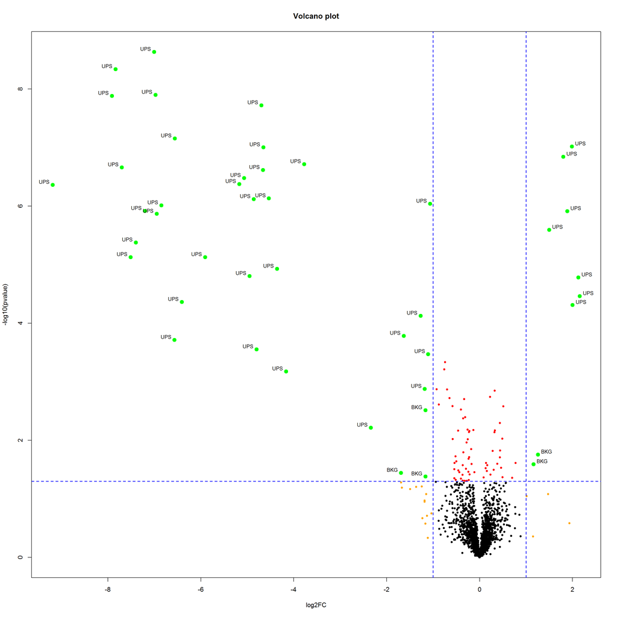

```r
with(res_mloG, plot(log2FC, -log10(pvalue), pch=20, main="Volcano plot"))
with(subset(res_mloG, pvalue < .05 ), points(log2FC, -log10(pvalue), pch=20, col="red"))
with(subset(res_mloG, abs(log2FC)>1), points(log2FC, -log10(pvalue), pch=20, col="orange"))
with(subset(res_mloG, pvalue<.05 & abs(log2FC)>1), points(log2FC, cex=2, -log10(pvalue), pch=20, col="green"))
with(subset(res_mloG, pvalue<.05 & abs(log2FC)>1), textxy(log2FC, -log10(pvalue), labs=UPS, cex=.8))
abline(h = -log10(0.05), v = c(-1,1), col = "blue", lty =2, lwd = 1.5)
```

Table 1: Up- and Down-regulated proteins given a Log2FC > 1 or -1 and pvalue below 0.05

```r
sigP <- (subset(res_mloG, abs(log2FC) > 1 & pvalue < 0.05))

sigP <- sigP[order(sigP$pvalue),]

kable(sigP)
```

|  | Protein2 | Protein | Label | log2FC | SE | Tvalue | DF | pvalue | adj.pvalue | threshold_1 | threshold_2 | threshold_3 | UPS | Log2FC.UPS2vsUPS1 | Ratio.UPS2vsUPS1 | AbsErrorRatio |
| --- | --- | --- | --- | --- | --- | --- | --- | --- | --- | --- | --- | --- | --- | --- | --- | --- |
| 2021 | P10599ups | P10599ups\|THIO_HUMAN_UPS | UPS2 vs UPS1 | -7.005182 | 0.1263875 | -55.426214 | 6 | 0.0000000 | 0.0000046 | TRUE | TRUE | TRUE | UPS | -6.643856 | 1e-02 | 22.155091 |
| 1999 | P01008ups | P01008ups\|ANT3_HUMAN_UPS | UPS2 vs UPS1 | -7.835158 | 0.1583618 | -49.476318 | 6 | 0.0000000 | 0.0000046 | TRUE | TRUE | TRUE | UPS | -6.643856 | 1e-02 | 56.209231 |
| 2004 | P01344ups | P01344ups\|IGF2_HUMAN_UPS | UPS2 vs UPS1 | -6.977785 | 0.1019861 | -68.419007 | 5 | 0.0000000 | 0.0000066 | TRUE | TRUE | TRUE | UPS | -6.643856 | 1e-02 | 20.662683 |
| 2014 | P05413ups | P05413ups\|FABPH_HUMAN_UPS | UPS2 vs UPS1 | -7.913276 | 0.1164699 | -67.942667 | 5 | 0.0000000 | 0.0000066 | TRUE | TRUE | TRUE | UPS | -13.287712 | 1e-04 | -4048.266787 |
| 2016 | P06732ups | P06732ups\|KCRM_HUMAN_UPS | UPS2 vs UPS1 | -4.698649 | 0.1204363 | -39.013562 | 6 | 0.0000000 | 0.0000077 | TRUE | TRUE | TRUE | UPS | -3.321928 | 1e-01 | 61.490689 |
| 2028 | P55957ups | P55957ups\|BID_HUMAN_UPS | UPS2 vs UPS1 | -6.561084 | 0.2092121 | -31.360924 | 6 | 0.0000001 | 0.0000236 | TRUE | TRUE | TRUE | UPS | -6.643856 | 1e-02 | -5.905119 |
| 2010 | P02768ups | P02768ups\|ALBU_HUMAN_UPS | UPS2 vs UPS1 | 1.985860 | 0.0667495 | 29.750924 | 6 | 0.0000001 | 0.0000250 | TRUE | TRUE | TRUE | UPS | 3.321928 | 1e+01 | 60.390137 |
| 2023 | P12081ups | P12081ups\|SYHC_HUMAN_UPS | UPS2 vs UPS1 | -4.656332 | 0.1573898 | -29.584702 | 6 | 0.0000001 | 0.0000250 | TRUE | TRUE | TRUE | UPS | -3.321928 | 1e-01 | 60.344402 |
| 1998 | P00918ups | P00918ups\|CAH2_HUMAN_UPS | UPS2 vs UPS1 | 1.798724 | 0.0647308 | 27.787752 | 6 | 0.0000001 | 0.0000323 | TRUE | TRUE | TRUE | UPS | 3.321928 | 1e+01 | 65.208760 |
| 2009 | P02753ups | P02753ups\|RETBP_HUMAN_UPS | UPS2 vs UPS1 | -3.777470 | 0.1428204 | -26.449090 | 6 | 0.0000002 | 0.0000391 | TRUE | TRUE | TRUE | UPS | -3.321928 | 1e-01 | 27.076358 |
| 2005 | P01375ups | P01375ups\|TNFA_HUMAN_UPS | UPS2 vs UPS1 | -7.702258 | 0.2972561 | -25.911186 | 6 | 0.0000002 | 0.0000401 | TRUE | TRUE | TRUE | UPS | -13.287712 | 1e-04 | -4701.637876 |
| 2025 | P16083ups | P16083ups\|NQO2_HUMAN_UPS | UPS2 vs UPS1 | -4.663880 | 0.1831952 | -25.458522 | 6 | 0.0000002 | 0.0000409 | TRUE | TRUE | TRUE | UPS | -3.321928 | 1e-01 | 60.551329 |
| 2015 | P06396ups | P06396ups\|GELS_HUMAN_UPS | UPS2 vs UPS1 | -5.069076 | 0.2098658 | -24.153887 | 6 | 0.0000003 | 0.0000516 | TRUE | TRUE | TRUE | UPS | -9.965784 | 1e-03 | -2878.901271 |
| 2039 | Q15843ups | Q15843ups\|NEDD8_HUMAN_UPS | UPS2 vs UPS1 | -5.173060 | 0.2229361 | -23.204226 | 6 | 0.0000004 | 0.0000585 | TRUE | TRUE | TRUE | UPS | -3.321928 | 1e-01 | 72.282526 |
| 2020 | P10145ups | P10145ups\|IL8_HUMAN_UPS | UPS2 vs UPS1 | -9.189667 | 0.0534267 | -172.005111 | 3 | 0.0000004 | 0.0000585 | TRUE | TRUE | TRUE | UPS | -13.287712 | 1e-04 | -1612.515374 |
| 2034 | P63279ups | P63279ups\|UBC9_HUMAN_UPS | UPS2 vs UPS1 | -4.535738 | 0.2146964 | -21.126289 | 6 | 0.0000007 | 0.0000907 | TRUE | TRUE | TRUE | UPS | -3.321928 | 1e-01 | 56.887150 |
| 2029 | P61626ups | P61626ups\|LYSC_HUMAN_UPS | UPS2 vs UPS1 | -4.860515 | 0.2315479 | -20.991407 | 6 | 0.0000008 | 0.0000907 | TRUE | TRUE | TRUE | UPS | -3.321928 | 1e-01 | 65.577758 |
| 2013 | P04040ups | P04040ups\|CATA_HUMAN_UPS | UPS2 vs UPS1 | -1.065829 | 0.0523615 | -20.355179 | 6 | 0.0000009 | 0.0001029 | TRUE | TRUE | TRUE | UPS | 0.000000 | 1e+00 | 52.230177 |
| 2017 | P08263ups | P08263ups\|GSTA1_HUMAN_UPS | UPS2 vs UPS1 | -6.850460 | 0.3399047 | -20.154061 | 6 | 0.0000010 | 0.0001033 | TRUE | TRUE | TRUE | UPS | -6.643856 | 1e-02 | 13.342540 |
| 2002 | P01127ups | P01127ups\|PDGFB_HUMAN_UPS | UPS2 vs UPS1 | -7.206180 | 0.2628337 | -27.417260 | 5 | 0.0000012 | 0.0001174 | TRUE | TRUE | TRUE | UPS | -6.643856 | 1e-02 | 32.278951 |
| 2032 | P62988ups | P62988ups\|UBIQ_HUMAN_UPS | UPS2 vs UPS1 | 1.886859 | 0.0972974 | 19.392704 | 6 | 0.0000012 | 0.0001174 | TRUE | TRUE | TRUE | UPS | 3.321928 | 1e+01 | 63.017085 |
| 2011 | P02787ups | P02787ups\|TRFE_HUMAN_UPS | UPS2 vs UPS1 | -6.948676 | 0.0589726 | -117.828868 | 3 | 0.0000013 | 0.0001241 | TRUE | TRUE | TRUE | UPS | -9.965784 | 1e-03 | -709.543231 |
| 2035 | P68871ups | P68871ups\|HBB_HUMAN_UPS | UPS2 vs UPS1 | 1.495520 | 0.0874105 | 17.109157 | 6 | 0.0000026 | 0.0002248 | TRUE | TRUE | TRUE | UPS | 3.321928 | 1e+01 | 71.803427 |
| 2018 | P08758ups | P08758ups\|ANXA5_HUMAN_UPS | UPS2 vs UPS1 | -7.400841 | 0.4703048 | -15.736265 | 6 | 0.0000042 | 0.0003524 | TRUE | TRUE | TRUE | UPS | -13.287712 | 1e-04 | -5817.318262 |
| 2012 | P02788ups | P02788ups\|TRFL_HUMAN_UPS | UPS2 vs UPS1 | -5.907576 | 0.4142241 | -14.261789 | 6 | 0.0000074 | 0.0005797 | TRUE | TRUE | TRUE | UPS | -13.287712 | 1e-04 | -16558.747034 |
| 2037 | P99999ups | P99999ups\|CYC_HUMAN_UPS | UPS2 vs UPS1 | -7.511379 | 0.2511204 | -29.911461 | 4 | 0.0000074 | 0.0005797 | TRUE | TRUE | TRUE | UPS | -9.965784 | 1e-03 | -448.087040 |
| 2022 | P10636-8ups | P10636-8ups\|TAU_HUMAN_UPS | UPS2 vs UPS1 | -4.359706 | 0.3306039 | -13.187100 | 6 | 0.0000117 | 0.0008810 | TRUE | TRUE | TRUE | UPS | -13.287712 | 1e-04 | -48607.711086 |
| 1992 | O00762ups | O00762ups\|UBE2C_HUMAN_UPS | UPS2 vs UPS1 | -4.953190 | 0.3944550 | -12.557046 | 6 | 0.0000156 | 0.0011294 | TRUE | TRUE | TRUE | UPS | -9.965784 | 1e-03 | -3128.057068 |
| 1997 | P00915ups | P00915ups\|CAH1_HUMAN_UPS | UPS2 vs UPS1 | 2.126234 | 0.1710793 | 12.428351 | 6 | 0.0000166 | 0.0011577 | TRUE | TRUE | TRUE | UPS | 3.321928 | 1e+01 | 56.342367 |
| 2026 | P41159ups | P41159ups\|LEP_HUMAN_UPS | UPS2 vs UPS1 | 2.154100 | 0.1966993 | 10.951237 | 6 | 0.0000344 | 0.0023246 | TRUE | TRUE | TRUE | UPS | 3.321928 | 1e+01 | 55.490904 |
| 1993 | O76070ups | O76070ups\|SYUG_HUMAN_UPS | UPS2 vs UPS1 | -6.409036 | 0.6092476 | -10.519592 | 6 | 0.0000434 | 0.0028337 | TRUE | TRUE | TRUE | UPS | -6.643856 | 1e-02 | -17.675990 |
| 2036 | P69905ups | P69905ups\|HBA_HUMAN_UPS | UPS2 vs UPS1 | 1.998815 | 0.1938465 | 10.311328 | 6 | 0.0000486 | 0.0030781 | TRUE | TRUE | TRUE | UPS | 3.321928 | 1e+01 | 60.032851 |
| 2024 | P15559ups | P15559ups\|NQO1_HUMAN_UPS | UPS2 vs UPS1 | -1.271416 | 0.1329214 | -9.565172 | 6 | 0.0000746 | 0.0045793 | TRUE | TRUE | TRUE | UPS | 0.000000 | 1e+00 | 58.574709 |
| 2007 | P02144ups | P02144ups\|MYG_HUMAN_UPS | UPS2 vs UPS1 | -1.631103 | 0.1961678 | -8.314837 | 6 | 0.0001641 | 0.0097806 | TRUE | TRUE | TRUE | UPS | 0.000000 | 1e+00 | 67.715880 |
| 2030 | P61769ups | P61769ups\|B2MG_HUMAN_UPS | UPS2 vs UPS1 | -6.567643 | 0.6731790 | -9.756161 | 5 | 0.0001924 | 0.0111377 | TRUE | TRUE | TRUE | UPS | -6.643856 | 1e-02 | -5.424701 |
| 1996 | P00709ups | P00709ups\|LALBA_HUMAN_UPS | UPS2 vs UPS1 | -4.799668 | 0.6352164 | -7.555958 | 6 | 0.0002789 | 0.0156978 | TRUE | TRUE | TRUE | UPS | -3.321928 | 1e-01 | 64.094917 |
| 2033 | P63165ups | P63165ups\|SUMO1_HUMAN_UPS | UPS2 vs UPS1 | -1.107250 | 0.1518415 | -7.292139 | 6 | 0.0003389 | 0.0185595 | TRUE | TRUE | TRUE | UPS | 0.000000 | 1e+00 | 53.582191 |
| 1995 | P00441ups | P00441ups\|SODC_HUMAN_UPS | UPS2 vs UPS1 | -4.165118 | 0.2812038 | -14.811740 | 3 | 0.0006677 | 0.0338182 | TRUE | TRUE | TRUE | UPS | -13.287712 | 1e-04 | -55640.983340 |
| 1994 | P00167ups | P00167ups\|CYB5_HUMAN_UPS | UPS2 vs UPS1 | -1.180824 | 0.2092907 | -5.642028 | 6 | 0.0013286 | 0.0637815 | TRUE | TRUE | TRUE | UPS | 0.000000 | 1e+00 | 55.890048 |
| 681 | gi | gi\|253772821\|ref\|YP_003035652.1\| | UPS2 vs UPS1 | -1.165031 | 0.2435804 | -4.782941 | 6 | 0.0030536 | 0.1189736 | TRUE | TRUE | TRUE | BKG | 0.000000 | 1e+00 | 55.404527 |
| 2019 | P09211ups | P09211ups\|GSTP1_HUMAN_UPS | UPS2 vs UPS1 | -2.339866 | 0.3363418 | -6.956810 | 3 | 0.0060932 | 0.2204422 | TRUE | TRUE | TRUE | UPS | -9.965784 | 1e-03 | -19652.869649 |
| 1268 | gi | gi\|253774103\|ref\|YP_003036934.1\| | UPS2 vs UPS1 | 1.254709 | 0.2635526 | 4.760754 | 3 | 0.0175966 | 0.4951496 | FALSE | TRUE | TRUE | BKG | 0.000000 | 1e+00 | -138.619082 |
| 1568 | gi | gi\|253774816\|ref\|YP_003037647.1\| | UPS2 vs UPS1 | 1.158086 | 0.3922508 | 2.952412 | 6 | 0.0255330 | 0.6232502 | FALSE | TRUE | TRUE | BKG | 0.000000 | 1e+00 | -123.161118 |
| 634 | gi | gi\|253772752\|ref\|YP_003035583.1\| | UPS2 vs UPS1 | -1.692714 | 0.6294202 | -2.689323 | 6 | 0.0360852 | 0.7615481 | FALSE | TRUE | TRUE | BKG | 0.000000 | 1e+00 | 69.065553 |
| 1991 | gi | gi\|253775663\|ref\|YP_003038494.1\| | UPS2 vs UPS1 | -1.165619 | 0.4510455 | -2.584260 | 6 | 0.0415309 | 0.8414170 | FALSE | TRUE | TRUE | BKG | 0.000000 | 1e+00 | 55.422704 |

Plot Measured against Expected Log2 FC for the significant proteins

```r
with(res_mloG, plot(log2FC, Log2FC.UPS2vsUPS1, pch=1))
with(subset(res_mloG, UPS == "UPS" ), points(log2FC, Log2FC.UPS2vsUPS1, pch=20, col="red"))
```

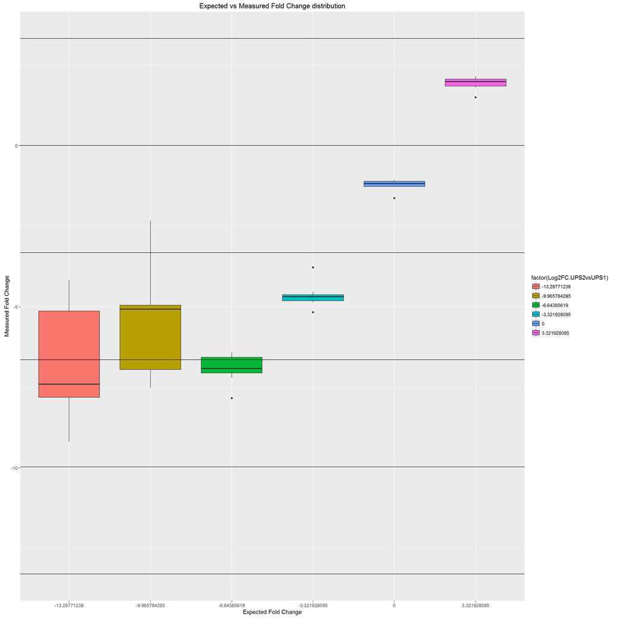

```r
b1 <- ggplot(subset(sigP, UPS=="UPS"), aes(factor(Log2FC.UPS2vsUPS1), log2FC))
b1 + geom_boxplot(aes(fill = factor(Log2FC.UPS2vsUPS1))) + geom_hline(yintercept=unique(sigP$Log2FC.UPS2vsUPS1)) +
  xlab("Expected Fold Change") + ylab("Measured Fold Change") + ggtitle("Expected vs Measured Fold Change distribution")
```

## Statistical test (MSstats) for differential protein abundance. Loess but with adjust.pvalue.

```r
#detach("package:Normalyzer", unload=TRUE)

# Loess normalization
pept_loGadj <- read.delim("normalization_peptides/Loess-G-normalized.txt")

# remove peptides non-unique for groups or proteins, select Sequence, Proteins and Intensities columns, and melt table
mloGadj <- melt(subset(pept_loGadj, Unique..Groups. == "yes" & Unique..Proteins. == "yes", select=c(1,2,6:ncol(pept_loGadj))), id.vars=1:2)
mloGadj$value <- 2^mloGadj$value

#pep2prot <- aggregate(mloGadj[,4], by=list(mloGadj$Protein, mloGadj$variable), function(x) sum(x, na.rm=TRUE))
#prots <- cast(pep2prot, Group.1 ~ Group.2, sum)
#colnames(pep.prot.melt) <- c("Leading.razor.protein", "SampleName", "Condition", "sumIntensity")

# add columns for MSstats
mloGadj$PrecursorCharge <- 2
mloGadj$FragmentIon <- NA
mloGadj$ProductCharge <- NA
mloGadj$IsotopeLabelType <- "L"
mloGadj <- merge(mloGadj, sampleInfo, by="variable",all=TRUE)

# Compare
mloGadj_10col <- mloGadj[,c(3,2,5:9,1,10,4)]
colnames(mloGadj_10col) <- c("ProteinName", "PeptideSequence", "PrecursorCharge","FragmentIon", "ProductCharge","IsotopeLabelType", "Condition","BioReplicate", "Run", "Intensity")


quant_mloGadj <- dataProcess(mloGadj_10col, normalization=FALSE)
```

```
##
##   Summary of Features :
##                          count
## # of Protein              2046
## # of Peptides/Protein     1-85
## # of Transitions/Peptide   1-1
##
##   Summary of Samples :
##                            EcoUPS1 EcoUPS2
## # of MS runs                     4       4
## # of Biological Replicates       4       4
## # of Technical Replicates        1       1
```

```r
levels(quant_mloGadj$ProcessedData$GROUP_ORIGINAL)
```

```
## [1] "EcoUPS1" "EcoUPS2"
```

```r
comparison<-matrix(c(-1,1),nrow=1)
row.names(comparison) <- "UPS2 vs UPS1"


#scopeOfTechReplication="expanded", scopeOfBioReplication="restricted",
comp_mloGadj <- groupComparison(contrast.matrix=comparison, data=quant_mloGadj)

res_mloGadj <- comp_mloGadj$ComparisonResult
res_mloGadj$threshold_1 = as.factor(abs(res_mloGadj$log2FC) > 1 & res_mloGadj$adj.pvalue < 0.01)
res_mloGadj$threshold_2 = as.factor(abs(res_mloGadj$log2FC) > 1 & res_mloGadj$adj.pvalue < 0.05)
res_mloGadj$threshold_3 = as.factor(abs(res_mloGadj$log2FC) > 0.8  & res_mloGadj$adj.pvalue < 0.05)
res_mloGadj$UPS <- ifelse(grepl("_UPS$",res_mloGadj$Protein), "UPS", "BKG")

spikes <- read.delim("spikes.txt")
res_mloGadj$Protein2 <- gsub("\\|.*","", res_mloGadj$Protein)
res_mloGadj <- merge(res_mloGadj, spikes, by.x="Protein2", by.y="Spike", all=TRUE)
res_mloGadj$Log2FC.UPS2vsUPS1[is.na(res_mloGadj$Log2FC.UPS2vsUPS1)] <- 0
res_mloGadj$Ratio.UPS2vsUPS1[is.na(res_mloGadj$Ratio.UPS2vsUPS1)] <- 1

res_mloGadj$AbsErrorRatio <- (res_mloGadj$Ratio.UPS2vsUPS1-(2^res_mloGadj$log2FC))/res_mloGadj$Ratio.UPS2vsUPS1*100
```

```r
# Threshold 1
kable(table(res_mloGadj$threshold_1, res_mloGadj$UPS))
```

|  | BKG | UPS |
| --- | --- | --- |
| FALSE | 1986 | 10 |
| TRUE | 0 | 34 |

```r
# Threshold 2
kable(table(res_mloGadj$threshold_2, res_mloGadj$UPS))
```

|  | BKG | UPS |
| --- | --- | --- |
| FALSE | 1986 | 6 |
| TRUE | 0 | 38 |

```r
# Threshold 3
kable(table(res_mloGadj$threshold_3, res_mloGadj$UPS))
```

|  | BKG | UPS |
| --- | --- | --- |
| FALSE | 1984 | 6 |
| TRUE | 0 | 38 |

```r
# Export
#write.table(res_mloGadj, file="MSstats_peptide_loessGADJ_UPS-Quant.txt", sep="\t", row.names=FALSE)
```

Volcano plot

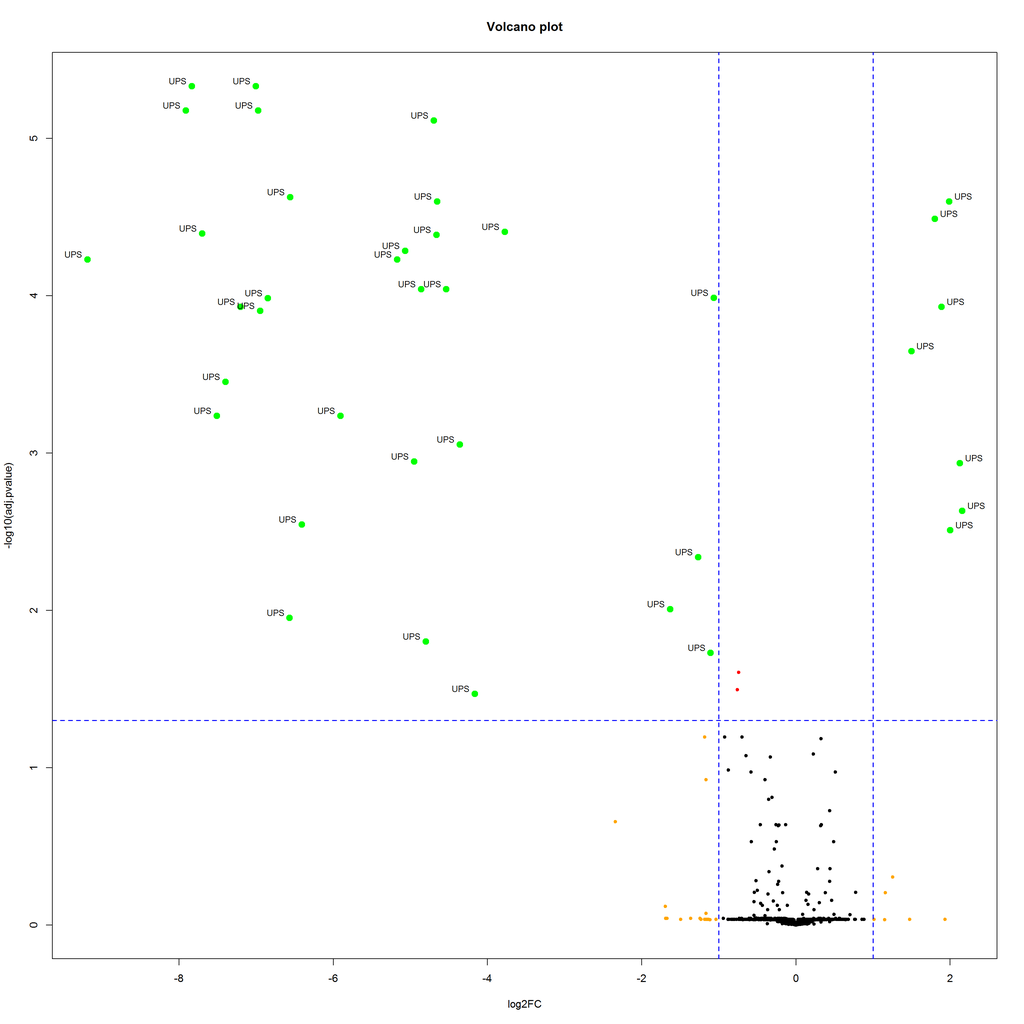

```r
with(res_mloGadj, plot(log2FC, -log10(adj.pvalue), pch=20, main="Volcano plot"))
with(subset(res_mloGadj, adj.pvalue < .05 ), points(log2FC, -log10(adj.pvalue), pch=20, col="red"))
with(subset(res_mloGadj, abs(log2FC)>1), points(log2FC, -log10(adj.pvalue), pch=20, col="orange"))
with(subset(res_mloGadj, adj.pvalue<.05 & abs(log2FC)>1), points(log2FC, cex=2, -log10(adj.pvalue), pch=20, col="green"))
with(subset(res_mloGadj, adj.pvalue<.05 & abs(log2FC)>1), textxy(log2FC, -log10(adj.pvalue), labs=UPS, cex=.8))
abline(h = -log10(0.05), v = c(-1,1), col = "blue", lty =2, lwd = 1.5)
```

Table 1: Up- and Down-regulated proteins given a Log2FC > 1 or -1 and adj.pvalue below 0.05

```r
sigP <- (subset(res_mloGadj, abs(log2FC) > 1 & adj.pvalue < 0.05))

sigP <- sigP[order(sigP$adj.pvalue),]

kable(sigP)
```

|  | Protein2 | Protein | Label | log2FC | SE | Tvalue | DF | pvalue | adj.pvalue | threshold_1 | threshold_2 | threshold_3 | UPS | Log2FC.UPS2vsUPS1 | Ratio.UPS2vsUPS1 | AbsErrorRatio |
| --- | --- | --- | --- | --- | --- | --- | --- | --- | --- | --- | --- | --- | --- | --- | --- | --- |
| 1999 | P01008ups | P01008ups\|ANT3_HUMAN_UPS | UPS2 vs UPS1 | -7.835158 | 0.1583618 | -49.476318 | 6 | 0.0000000 | 0.0000046 | TRUE | TRUE | TRUE | UPS | -6.643856 | 1e-02 | 56.209231 |
| 2021 | P10599ups | P10599ups\|THIO_HUMAN_UPS | UPS2 vs UPS1 | -7.005182 | 0.1263875 | -55.426214 | 6 | 0.0000000 | 0.0000046 | TRUE | TRUE | TRUE | UPS | -6.643856 | 1e-02 | 22.155091 |
| 2004 | P01344ups | P01344ups\|IGF2_HUMAN_UPS | UPS2 vs UPS1 | -6.977785 | 0.1019861 | -68.419007 | 5 | 0.0000000 | 0.0000066 | TRUE | TRUE | TRUE | UPS | -6.643856 | 1e-02 | 20.662683 |
| 2014 | P05413ups | P05413ups\|FABPH_HUMAN_UPS | UPS2 vs UPS1 | -7.913276 | 0.1164699 | -67.942667 | 5 | 0.0000000 | 0.0000066 | TRUE | TRUE | TRUE | UPS | -13.287712 | 1e-04 | -4048.266787 |
| 2016 | P06732ups | P06732ups\|KCRM_HUMAN_UPS | UPS2 vs UPS1 | -4.698649 | 0.1204363 | -39.013562 | 6 | 0.0000000 | 0.0000077 | TRUE | TRUE | TRUE | UPS | -3.321928 | 1e-01 | 61.490689 |
| 2028 | P55957ups | P55957ups\|BID_HUMAN_UPS | UPS2 vs UPS1 | -6.561084 | 0.2092121 | -31.360924 | 6 | 0.0000001 | 0.0000236 | TRUE | TRUE | TRUE | UPS | -6.643856 | 1e-02 | -5.905119 |
| 2010 | P02768ups | P02768ups\|ALBU_HUMAN_UPS | UPS2 vs UPS1 | 1.985860 | 0.0667495 | 29.750924 | 6 | 0.0000001 | 0.0000250 | TRUE | TRUE | TRUE | UPS | 3.321928 | 1e+01 | 60.390137 |
| 2023 | P12081ups | P12081ups\|SYHC_HUMAN_UPS | UPS2 vs UPS1 | -4.656332 | 0.1573898 | -29.584702 | 6 | 0.0000001 | 0.0000250 | TRUE | TRUE | TRUE | UPS | -3.321928 | 1e-01 | 60.344402 |
| 1998 | P00918ups | P00918ups\|CAH2_HUMAN_UPS | UPS2 vs UPS1 | 1.798724 | 0.0647308 | 27.787752 | 6 | 0.0000001 | 0.0000323 | TRUE | TRUE | TRUE | UPS | 3.321928 | 1e+01 | 65.208760 |
| 2009 | P02753ups | P02753ups\|RETBP_HUMAN_UPS | UPS2 vs UPS1 | -3.777470 | 0.1428204 | -26.449090 | 6 | 0.0000002 | 0.0000391 | TRUE | TRUE | TRUE | UPS | -3.321928 | 1e-01 | 27.076358 |
| 2005 | P01375ups | P01375ups\|TNFA_HUMAN_UPS | UPS2 vs UPS1 | -7.702258 | 0.2972561 | -25.911186 | 6 | 0.0000002 | 0.0000401 | TRUE | TRUE | TRUE | UPS | -13.287712 | 1e-04 | -4701.637876 |
| 2025 | P16083ups | P16083ups\|NQO2_HUMAN_UPS | UPS2 vs UPS1 | -4.663880 | 0.1831952 | -25.458522 | 6 | 0.0000002 | 0.0000409 | TRUE | TRUE | TRUE | UPS | -3.321928 | 1e-01 | 60.551329 |
| 2015 | P06396ups | P06396ups\|GELS_HUMAN_UPS | UPS2 vs UPS1 | -5.069076 | 0.2098658 | -24.153887 | 6 | 0.0000003 | 0.0000516 | TRUE | TRUE | TRUE | UPS | -9.965784 | 1e-03 | -2878.901271 |
| 2020 | P10145ups | P10145ups\|IL8_HUMAN_UPS | UPS2 vs UPS1 | -9.189667 | 0.0534267 | -172.005111 | 3 | 0.0000004 | 0.0000585 | TRUE | TRUE | TRUE | UPS | -13.287712 | 1e-04 | -1612.515374 |
| 2039 | Q15843ups | Q15843ups\|NEDD8_HUMAN_UPS | UPS2 vs UPS1 | -5.173060 | 0.2229361 | -23.204226 | 6 | 0.0000004 | 0.0000585 | TRUE | TRUE | TRUE | UPS | -3.321928 | 1e-01 | 72.282526 |
| 2029 | P61626ups | P61626ups\|LYSC_HUMAN_UPS | UPS2 vs UPS1 | -4.860515 | 0.2315479 | -20.991407 | 6 | 0.0000008 | 0.0000907 | TRUE | TRUE | TRUE | UPS | -3.321928 | 1e-01 | 65.577758 |
| 2034 | P63279ups | P63279ups\|UBC9_HUMAN_UPS | UPS2 vs UPS1 | -4.535738 | 0.2146964 | -21.126289 | 6 | 0.0000007 | 0.0000907 | TRUE | TRUE | TRUE | UPS | -3.321928 | 1e-01 | 56.887150 |
| 2013 | P04040ups | P04040ups\|CATA_HUMAN_UPS | UPS2 vs UPS1 | -1.065829 | 0.0523615 | -20.355179 | 6 | 0.0000009 | 0.0001029 | TRUE | TRUE | TRUE | UPS | 0.000000 | 1e+00 | 52.230177 |
| 2017 | P08263ups | P08263ups\|GSTA1_HUMAN_UPS | UPS2 vs UPS1 | -6.850460 | 0.3399047 | -20.154061 | 6 | 0.0000010 | 0.0001033 | TRUE | TRUE | TRUE | UPS | -6.643856 | 1e-02 | 13.342540 |
| 2002 | P01127ups | P01127ups\|PDGFB_HUMAN_UPS | UPS2 vs UPS1 | -7.206180 | 0.2628337 | -27.417260 | 5 | 0.0000012 | 0.0001174 | TRUE | TRUE | TRUE | UPS | -6.643856 | 1e-02 | 32.278951 |
| 2032 | P62988ups | P62988ups\|UBIQ_HUMAN_UPS | UPS2 vs UPS1 | 1.886859 | 0.0972974 | 19.392704 | 6 | 0.0000012 | 0.0001174 | TRUE | TRUE | TRUE | UPS | 3.321928 | 1e+01 | 63.017085 |
| 2011 | P02787ups | P02787ups\|TRFE_HUMAN_UPS | UPS2 vs UPS1 | -6.948676 | 0.0589726 | -117.828868 | 3 | 0.0000013 | 0.0001241 | TRUE | TRUE | TRUE | UPS | -9.965784 | 1e-03 | -709.543231 |
| 2035 | P68871ups | P68871ups\|HBB_HUMAN_UPS | UPS2 vs UPS1 | 1.495520 | 0.0874105 | 17.109157 | 6 | 0.0000026 | 0.0002248 | TRUE | TRUE | TRUE | UPS | 3.321928 | 1e+01 | 71.803427 |
| 2018 | P08758ups | P08758ups\|ANXA5_HUMAN_UPS | UPS2 vs UPS1 | -7.400841 | 0.4703048 | -15.736265 | 6 | 0.0000042 | 0.0003524 | TRUE | TRUE | TRUE | UPS | -13.287712 | 1e-04 | -5817.318262 |
| 2012 | P02788ups | P02788ups\|TRFL_HUMAN_UPS | UPS2 vs UPS1 | -5.907576 | 0.4142241 | -14.261789 | 6 | 0.0000074 | 0.0005797 | TRUE | TRUE | TRUE | UPS | -13.287712 | 1e-04 | -16558.747034 |
| 2037 | P99999ups | P99999ups\|CYC_HUMAN_UPS | UPS2 vs UPS1 | -7.511379 | 0.2511204 | -29.911461 | 4 | 0.0000074 | 0.0005797 | TRUE | TRUE | TRUE | UPS | -9.965784 | 1e-03 | -448.087040 |
| 2022 | P10636-8ups | P10636-8ups\|TAU_HUMAN_UPS | UPS2 vs UPS1 | -4.359706 | 0.3306039 | -13.187100 | 6 | 0.0000117 | 0.0008810 | TRUE | TRUE | TRUE | UPS | -13.287712 | 1e-04 | -48607.711086 |
| 1992 | O00762ups | O00762ups\|UBE2C_HUMAN_UPS | UPS2 vs UPS1 | -4.953190 | 0.3944550 | -12.557046 | 6 | 0.0000156 | 0.0011294 | TRUE | TRUE | TRUE | UPS | -9.965784 | 1e-03 | -3128.057068 |
| 1997 | P00915ups | P00915ups\|CAH1_HUMAN_UPS | UPS2 vs UPS1 | 2.126234 | 0.1710793 | 12.428351 | 6 | 0.0000166 | 0.0011577 | TRUE | TRUE | TRUE | UPS | 3.321928 | 1e+01 | 56.342367 |
| 2026 | P41159ups | P41159ups\|LEP_HUMAN_UPS | UPS2 vs UPS1 | 2.154100 | 0.1966993 | 10.951237 | 6 | 0.0000344 | 0.0023246 | TRUE | TRUE | TRUE | UPS | 3.321928 | 1e+01 | 55.490904 |
| 1993 | O76070ups | O76070ups\|SYUG_HUMAN_UPS | UPS2 vs UPS1 | -6.409036 | 0.6092476 | -10.519592 | 6 | 0.0000434 | 0.0028337 | TRUE | TRUE | TRUE | UPS | -6.643856 | 1e-02 | -17.675990 |
| 2036 | P69905ups | P69905ups\|HBA_HUMAN_UPS | UPS2 vs UPS1 | 1.998815 | 0.1938465 | 10.311328 | 6 | 0.0000486 | 0.0030781 | TRUE | TRUE | TRUE | UPS | 3.321928 | 1e+01 | 60.032851 |
| 2024 | P15559ups | P15559ups\|NQO1_HUMAN_UPS | UPS2 vs UPS1 | -1.271416 | 0.1329214 | -9.565172 | 6 | 0.0000746 | 0.0045793 | TRUE | TRUE | TRUE | UPS | 0.000000 | 1e+00 | 58.574709 |
| 2007 | P02144ups | P02144ups\|MYG_HUMAN_UPS | UPS2 vs UPS1 | -1.631103 | 0.1961678 | -8.314837 | 6 | 0.0001641 | 0.0097806 | TRUE | TRUE | TRUE | UPS | 0.000000 | 1e+00 | 67.715880 |
| 2030 | P61769ups | P61769ups\|B2MG_HUMAN_UPS | UPS2 vs UPS1 | -6.567643 | 0.6731790 | -9.756161 | 5 | 0.0001924 | 0.0111377 | FALSE | TRUE | TRUE | UPS | -6.643856 | 1e-02 | -5.424701 |
| 1996 | P00709ups | P00709ups\|LALBA_HUMAN_UPS | UPS2 vs UPS1 | -4.799668 | 0.6352164 | -7.555958 | 6 | 0.0002789 | 0.0156978 | FALSE | TRUE | TRUE | UPS | -3.321928 | 1e-01 | 64.094917 |
| 2033 | P63165ups | P63165ups\|SUMO1_HUMAN_UPS | UPS2 vs UPS1 | -1.107250 | 0.1518415 | -7.292139 | 6 | 0.0003389 | 0.0185595 | FALSE | TRUE | TRUE | UPS | 0.000000 | 1e+00 | 53.582191 |
| 1995 | P00441ups | P00441ups\|SODC_HUMAN_UPS | UPS2 vs UPS1 | -4.165118 | 0.2812038 | -14.811740 | 3 | 0.0006677 | 0.0338182 | FALSE | TRUE | TRUE | UPS | -13.287712 | 1e-04 | -55640.983340 |

Plot Measured against Expected Log2 FC for the significant proteins

```r
with(res_mloGadj, plot(log2FC, Log2FC.UPS2vsUPS1, pch=1))
with(subset(res_mloGadj, UPS == "UPS" ), points(log2FC, Log2FC.UPS2vsUPS1, pch=20, col="red"))
```

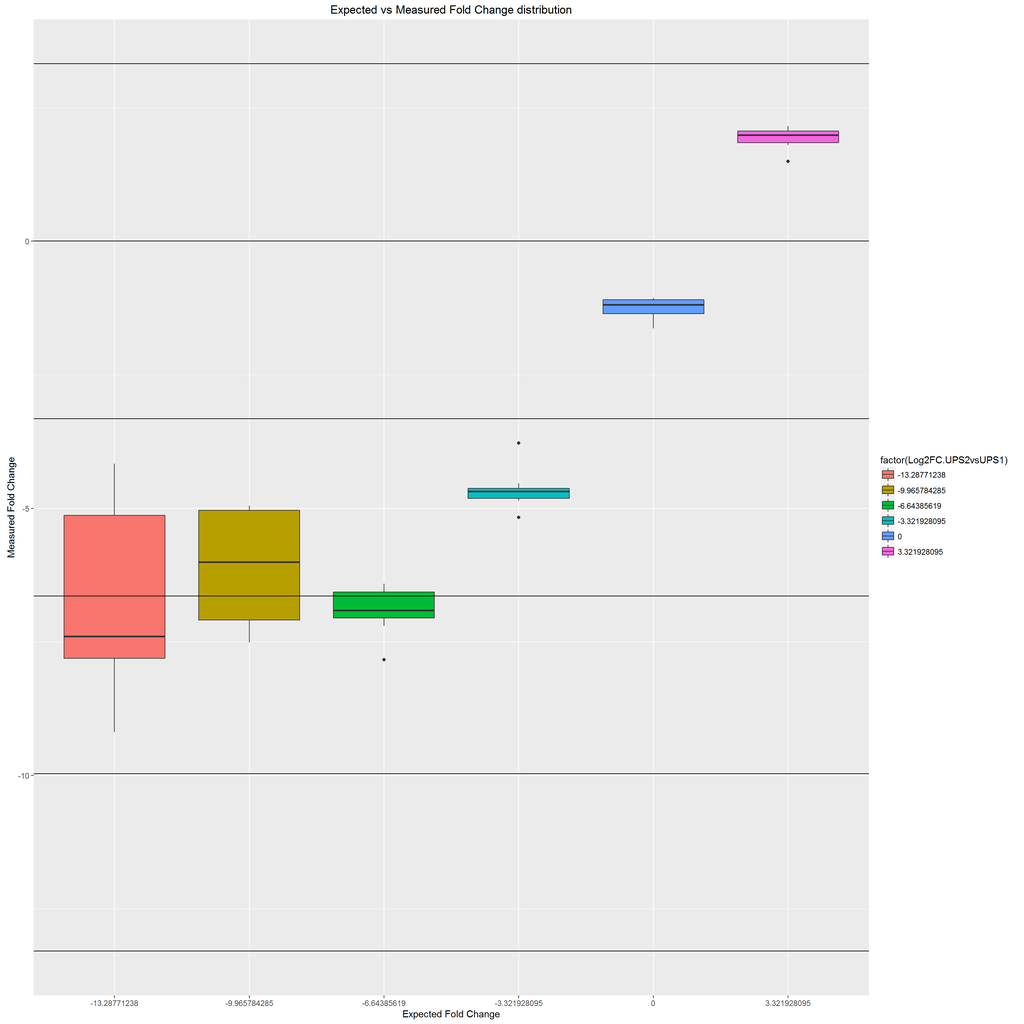

```r
b1 <- ggplot(subset(sigP, UPS=="UPS"), aes(factor(Log2FC.UPS2vsUPS1), log2FC))
b1 + geom_boxplot(aes(fill = factor(Log2FC.UPS2vsUPS1))) + geom_hline(yintercept=unique(sigP$Log2FC.UPS2vsUPS1)) +
  xlab("Expected Fold Change") + ylab("Measured Fold Change") + ggtitle("Expected vs Measured Fold Change distribution")
```

```r
#detach("package:Normalyzer", unload=TRUE)

# Loess normalization
pept_raw <- read.delim("normalization_peptides/Log2-normalized.txt")

# remove peptides non-unique for groups or proteins, select Sequence, Proteins and Intensities columns, and melt table
mraw <- melt(subset(pept_raw, Unique..Groups. == "yes" & Unique..Proteins. == "yes", select=c(1,2,6:ncol(pept_raw))), id.vars=1:2)

mraw$value <- 2^mraw$value
#pep2prot <- aggregate(mloG[,4], by=list(mloG$Protein, mloG$variable), function(x) sum(x, na.rm=TRUE))
#prots <- cast(pep2prot, Group.1 ~ Group.2, sum)
#colnames(pep.prot.melt) <- c("Leading.razor.protein", "SampleName", "Condition", "sumIntensity")

# add columns for MSstats
mraw$PrecursorCharge <- 2
mraw$FragmentIon <- NA
mraw$ProductCharge <- NA
mraw$IsotopeLabelType <- "L"
mraw <- merge(mraw, sampleInfo, by="variable",all=TRUE)

# Compare
mraw_10col <- mraw[,c(3,2,5:9,1,10,4)]
colnames(mraw_10col) <- c("ProteinName", "PeptideSequence", "PrecursorCharge","FragmentIon", "ProductCharge","IsotopeLabelType", "Condition","BioReplicate", "Run", "Intensity")


quant_mraw <- dataProcess(mraw_10col, normalization=FALSE)
```

```
##
##   Summary of Features :
##                          count
## # of Protein              2046
## # of Peptides/Protein     1-85
## # of Transitions/Peptide   1-1
##
##   Summary of Samples :
##                            EcoUPS1 EcoUPS2
## # of MS runs                     4       4
## # of Biological Replicates       4       4
## # of Technical Replicates        1       1
```

```r
levels(quant_mraw$ProcessedData$GROUP_ORIGINAL)
```

```
## [1] "EcoUPS1" "EcoUPS2"
```

```r
comparison<-matrix(c(-1,1),nrow=1)
row.names(comparison) <- "UPS2 vs UPS1"



#scopeOfTechReplication="expanded", scopeOfBioReplication="restricted",
comp_mraw <- groupComparison(contrast.matrix=comparison, data=quant_mloG)

res_mraw <- comp_mraw$ComparisonResult
res_mraw$threshold_1 = as.factor(abs(res_mraw$log2FC) > 1 & res_mraw$pvalue < 0.01)
res_mraw$threshold_2 = as.factor(abs(res_mraw$log2FC) > 1 & res_mraw$pvalue < 0.05)
res_mraw$threshold_3 = as.factor(abs(res_mraw$log2FC) > 0.8  & res_mraw$pvalue < 0.05)
res_mraw$UPS <- ifelse(grepl("_UPS$",res_mraw$Protein), "UPS", "BKG")

spikes <- read.delim("spikes.txt")
res_mraw$Protein2 <- gsub("\\|.*","", res_mraw$Protein)
res_mraw <- merge(res_mraw, spikes, by.x="Protein2", by.y="Spike", all=TRUE)
res_mraw$Log2FC.UPS2vsUPS1[is.na(res_mraw$Log2FC.UPS2vsUPS1)] <- 0
res_mraw$Ratio.UPS2vsUPS1[is.na(res_mraw$Ratio.UPS2vsUPS1)] <- 1

res_mraw$AbsErrorRatio <- (res_mraw$Ratio.UPS2vsUPS1-(2^res_mraw$Log2FC))/res_mraw$Ratio.UPS2vsUPS1*100
```

```r
# Threshold 1
kable(table(res_mraw$threshold_1, res_mraw$UPS))
```

|  | BKG | UPS |
| --- | --- | --- |
| FALSE | 1985 | 4 |
| TRUE | 1 | 40 |

```r
# Threshold 2
kable(table(res_mraw$threshold_2, res_mraw$UPS))
```

|  | BKG | UPS |
| --- | --- | --- |
| FALSE | 1981 | 4 |
| TRUE | 5 | 40 |

```r
# Threshold 3
kable(table(res_mraw$threshold_3, res_mraw$UPS))
```

|  | BKG | UPS |
| --- | --- | --- |
| FALSE | 1979 | 2 |
| TRUE | 5 | 42 |

```r
# Export
#write.table(res_mraw, file="MSstats_peptide_RAW_UPS-Quant.txt", sep="\t", row.names=FALSE)
```

Volcano plot

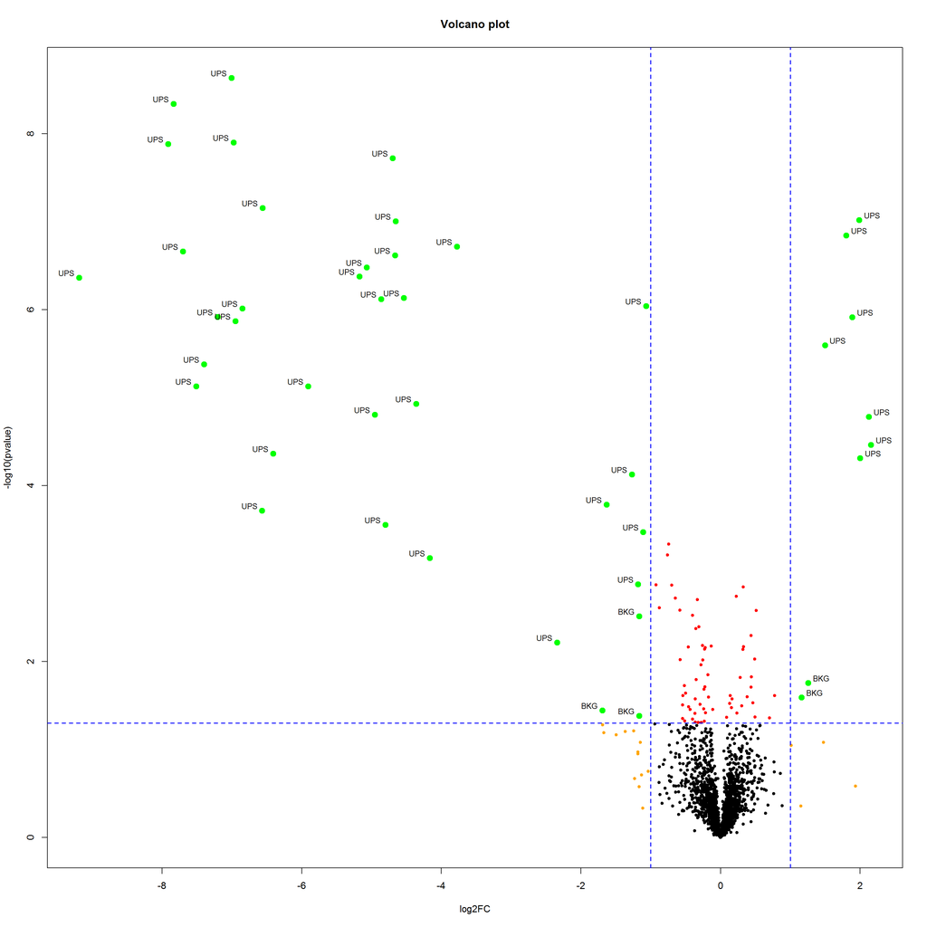

```r
with(res_mraw, plot(log2FC, -log10(pvalue), pch=20, main="Volcano plot"))
with(subset(res_mraw, pvalue < .05 ), points(log2FC, -log10(pvalue), pch=20, col="red"))
with(subset(res_mraw, abs(log2FC)>1), points(log2FC, -log10(pvalue), pch=20, col="orange"))
with(subset(res_mraw, pvalue<.05 & abs(log2FC)>1), points(log2FC, cex=2, -log10(pvalue), pch=20, col="green"))
with(subset(res_mraw, pvalue<.05 & abs(log2FC)>1), textxy(log2FC, -log10(pvalue), labs=UPS, cex=.8))
abline(h = -log10(0.05), v = c(-1,1), col = "blue", lty =2, lwd = 1.5)
```

Table 1: Up- and Down-regulated proteins given a Log2FC > 1 or -1 and pvalue below 0.05

```r
sigP <- (subset(res_mraw, abs(log2FC) > 1 & pvalue < 0.05))

sigP <- sigP[order(sigP$pvalue),]

kable(sigP)
```

|  | Protein2 | Protein | Label | log2FC | SE | Tvalue | DF | pvalue | adj.pvalue | threshold_1 | threshold_2 | threshold_3 | UPS | Log2FC.UPS2vsUPS1 | Ratio.UPS2vsUPS1 | AbsErrorRatio |
| --- | --- | --- | --- | --- | --- | --- | --- | --- | --- | --- | --- | --- | --- | --- | --- | --- |
| 2021 | P10599ups | P10599ups\|THIO_HUMAN_UPS | UPS2 vs UPS1 | -7.005182 | 0.1263875 | -55.426214 | 6 | 0.0000000 | 0.0000046 | TRUE | TRUE | TRUE | UPS | -6.643856 | 1e-02 | 0 |
| 1999 | P01008ups | P01008ups\|ANT3_HUMAN_UPS | UPS2 vs UPS1 | -7.835158 | 0.1583618 | -49.476318 | 6 | 0.0000000 | 0.0000046 | TRUE | TRUE | TRUE | UPS | -6.643856 | 1e-02 | 0 |
| 2004 | P01344ups | P01344ups\|IGF2_HUMAN_UPS | UPS2 vs UPS1 | -6.977785 | 0.1019861 | -68.419007 | 5 | 0.0000000 | 0.0000066 | TRUE | TRUE | TRUE | UPS | -6.643856 | 1e-02 | 0 |
| 2014 | P05413ups | P05413ups\|FABPH_HUMAN_UPS | UPS2 vs UPS1 | -7.913276 | 0.1164699 | -67.942667 | 5 | 0.0000000 | 0.0000066 | TRUE | TRUE | TRUE | UPS | -13.287712 | 1e-04 | 0 |
| 2016 | P06732ups | P06732ups\|KCRM_HUMAN_UPS | UPS2 vs UPS1 | -4.698649 | 0.1204363 | -39.013562 | 6 | 0.0000000 | 0.0000077 | TRUE | TRUE | TRUE | UPS | -3.321928 | 1e-01 | 0 |
| 2028 | P55957ups | P55957ups\|BID_HUMAN_UPS | UPS2 vs UPS1 | -6.561084 | 0.2092121 | -31.360924 | 6 | 0.0000001 | 0.0000236 | TRUE | TRUE | TRUE | UPS | -6.643856 | 1e-02 | 0 |
| 2010 | P02768ups | P02768ups\|ALBU_HUMAN_UPS | UPS2 vs UPS1 | 1.985860 | 0.0667495 | 29.750924 | 6 | 0.0000001 | 0.0000250 | TRUE | TRUE | TRUE | UPS | 3.321928 | 1e+01 | 0 |
| 2023 | P12081ups | P12081ups\|SYHC_HUMAN_UPS | UPS2 vs UPS1 | -4.656332 | 0.1573898 | -29.584702 | 6 | 0.0000001 | 0.0000250 | TRUE | TRUE | TRUE | UPS | -3.321928 | 1e-01 | 0 |
| 1998 | P00918ups | P00918ups\|CAH2_HUMAN_UPS | UPS2 vs UPS1 | 1.798724 | 0.0647308 | 27.787752 | 6 | 0.0000001 | 0.0000323 | TRUE | TRUE | TRUE | UPS | 3.321928 | 1e+01 | 0 |
| 2009 | P02753ups | P02753ups\|RETBP_HUMAN_UPS | UPS2 vs UPS1 | -3.777470 | 0.1428204 | -26.449090 | 6 | 0.0000002 | 0.0000391 | TRUE | TRUE | TRUE | UPS | -3.321928 | 1e-01 | 0 |
| 2005 | P01375ups | P01375ups\|TNFA_HUMAN_UPS | UPS2 vs UPS1 | -7.702258 | 0.2972561 | -25.911186 | 6 | 0.0000002 | 0.0000401 | TRUE | TRUE | TRUE | UPS | -13.287712 | 1e-04 | 0 |
| 2025 | P16083ups | P16083ups\|NQO2_HUMAN_UPS | UPS2 vs UPS1 | -4.663880 | 0.1831952 | -25.458522 | 6 | 0.0000002 | 0.0000409 | TRUE | TRUE | TRUE | UPS | -3.321928 | 1e-01 | 0 |
| 2015 | P06396ups | P06396ups\|GELS_HUMAN_UPS | UPS2 vs UPS1 | -5.069076 | 0.2098658 | -24.153887 | 6 | 0.0000003 | 0.0000516 | TRUE | TRUE | TRUE | UPS | -9.965784 | 1e-03 | 0 |
| 2039 | Q15843ups | Q15843ups\|NEDD8_HUMAN_UPS | UPS2 vs UPS1 | -5.173060 | 0.2229361 | -23.204226 | 6 | 0.0000004 | 0.0000585 | TRUE | TRUE | TRUE | UPS | -3.321928 | 1e-01 | 0 |
| 2020 | P10145ups | P10145ups\|IL8_HUMAN_UPS | UPS2 vs UPS1 | -9.189667 | 0.0534267 | -172.005111 | 3 | 0.0000004 | 0.0000585 | TRUE | TRUE | TRUE | UPS | -13.287712 | 1e-04 | 0 |
| 2034 | P63279ups | P63279ups\|UBC9_HUMAN_UPS | UPS2 vs UPS1 | -4.535738 | 0.2146964 | -21.126289 | 6 | 0.0000007 | 0.0000907 | TRUE | TRUE | TRUE | UPS | -3.321928 | 1e-01 | 0 |
| 2029 | P61626ups | P61626ups\|LYSC_HUMAN_UPS | UPS2 vs UPS1 | -4.860515 | 0.2315479 | -20.991407 | 6 | 0.0000008 | 0.0000907 | TRUE | TRUE | TRUE | UPS | -3.321928 | 1e-01 | 0 |
| 2013 | P04040ups | P04040ups\|CATA_HUMAN_UPS | UPS2 vs UPS1 | -1.065829 | 0.0523615 | -20.355179 | 6 | 0.0000009 | 0.0001029 | TRUE | TRUE | TRUE | UPS | 0.000000 | 1e+00 | 0 |
| 2017 | P08263ups | P08263ups\|GSTA1_HUMAN_UPS | UPS2 vs UPS1 | -6.850460 | 0.3399047 | -20.154061 | 6 | 0.0000010 | 0.0001033 | TRUE | TRUE | TRUE | UPS | -6.643856 | 1e-02 | 0 |
| 2002 | P01127ups | P01127ups\|PDGFB_HUMAN_UPS | UPS2 vs UPS1 | -7.206180 | 0.2628337 | -27.417260 | 5 | 0.0000012 | 0.0001174 | TRUE | TRUE | TRUE | UPS | -6.643856 | 1e-02 | 0 |
| 2032 | P62988ups | P62988ups\|UBIQ_HUMAN_UPS | UPS2 vs UPS1 | 1.886859 | 0.0972974 | 19.392704 | 6 | 0.0000012 | 0.0001174 | TRUE | TRUE | TRUE | UPS | 3.321928 | 1e+01 | 0 |
| 2011 | P02787ups | P02787ups\|TRFE_HUMAN_UPS | UPS2 vs UPS1 | -6.948676 | 0.0589726 | -117.828868 | 3 | 0.0000013 | 0.0001241 | TRUE | TRUE | TRUE | UPS | -9.965784 | 1e-03 | 0 |
| 2035 | P68871ups | P68871ups\|HBB_HUMAN_UPS | UPS2 vs UPS1 | 1.495520 | 0.0874105 | 17.109157 | 6 | 0.0000026 | 0.0002248 | TRUE | TRUE | TRUE | UPS | 3.321928 | 1e+01 | 0 |
| 2018 | P08758ups | P08758ups\|ANXA5_HUMAN_UPS | UPS2 vs UPS1 | -7.400841 | 0.4703048 | -15.736265 | 6 | 0.0000042 | 0.0003524 | TRUE | TRUE | TRUE | UPS | -13.287712 | 1e-04 | 0 |
| 2012 | P02788ups | P02788ups\|TRFL_HUMAN_UPS | UPS2 vs UPS1 | -5.907576 | 0.4142241 | -14.261789 | 6 | 0.0000074 | 0.0005797 | TRUE | TRUE | TRUE | UPS | -13.287712 | 1e-04 | 0 |
| 2037 | P99999ups | P99999ups\|CYC_HUMAN_UPS | UPS2 vs UPS1 | -7.511379 | 0.2511204 | -29.911461 | 4 | 0.0000074 | 0.0005797 | TRUE | TRUE | TRUE | UPS | -9.965784 | 1e-03 | 0 |
| 2022 | P10636-8ups | P10636-8ups\|TAU_HUMAN_UPS | UPS2 vs UPS1 | -4.359706 | 0.3306039 | -13.187100 | 6 | 0.0000117 | 0.0008810 | TRUE | TRUE | TRUE | UPS | -13.287712 | 1e-04 | 0 |
| 1992 | O00762ups | O00762ups\|UBE2C_HUMAN_UPS | UPS2 vs UPS1 | -4.953190 | 0.3944550 | -12.557046 | 6 | 0.0000156 | 0.0011294 | TRUE | TRUE | TRUE | UPS | -9.965784 | 1e-03 | 0 |
| 1997 | P00915ups | P00915ups\|CAH1_HUMAN_UPS | UPS2 vs UPS1 | 2.126234 | 0.1710793 | 12.428351 | 6 | 0.0000166 | 0.0011577 | TRUE | TRUE | TRUE | UPS | 3.321928 | 1e+01 | 0 |
| 2026 | P41159ups | P41159ups\|LEP_HUMAN_UPS | UPS2 vs UPS1 | 2.154100 | 0.1966993 | 10.951237 | 6 | 0.0000344 | 0.0023246 | TRUE | TRUE | TRUE | UPS | 3.321928 | 1e+01 | 0 |
| 1993 | O76070ups | O76070ups\|SYUG_HUMAN_UPS | UPS2 vs UPS1 | -6.409036 | 0.6092476 | -10.519592 | 6 | 0.0000434 | 0.0028337 | TRUE | TRUE | TRUE | UPS | -6.643856 | 1e-02 | 0 |
| 2036 | P69905ups | P69905ups\|HBA_HUMAN_UPS | UPS2 vs UPS1 | 1.998815 | 0.1938465 | 10.311328 | 6 | 0.0000486 | 0.0030781 | TRUE | TRUE | TRUE | UPS | 3.321928 | 1e+01 | 0 |
| 2024 | P15559ups | P15559ups\|NQO1_HUMAN_UPS | UPS2 vs UPS1 | -1.271416 | 0.1329214 | -9.565172 | 6 | 0.0000746 | 0.0045793 | TRUE | TRUE | TRUE | UPS | 0.000000 | 1e+00 | 0 |
| 2007 | P02144ups | P02144ups\|MYG_HUMAN_UPS | UPS2 vs UPS1 | -1.631103 | 0.1961678 | -8.314837 | 6 | 0.0001641 | 0.0097806 | TRUE | TRUE | TRUE | UPS | 0.000000 | 1e+00 | 0 |
| 2030 | P61769ups | P61769ups\|B2MG_HUMAN_UPS | UPS2 vs UPS1 | -6.567643 | 0.6731790 | -9.756161 | 5 | 0.0001924 | 0.0111377 | TRUE | TRUE | TRUE | UPS | -6.643856 | 1e-02 | 0 |
| 1996 | P00709ups | P00709ups\|LALBA_HUMAN_UPS | UPS2 vs UPS1 | -4.799668 | 0.6352164 | -7.555958 | 6 | 0.0002789 | 0.0156978 | TRUE | TRUE | TRUE | UPS | -3.321928 | 1e-01 | 0 |
| 2033 | P63165ups | P63165ups\|SUMO1_HUMAN_UPS | UPS2 vs UPS1 | -1.107250 | 0.1518415 | -7.292139 | 6 | 0.0003389 | 0.0185595 | TRUE | TRUE | TRUE | UPS | 0.000000 | 1e+00 | 0 |
| 1995 | P00441ups | P00441ups\|SODC_HUMAN_UPS | UPS2 vs UPS1 | -4.165118 | 0.2812038 | -14.811740 | 3 | 0.0006677 | 0.0338182 | TRUE | TRUE | TRUE | UPS | -13.287712 | 1e-04 | 0 |
| 1994 | P00167ups | P00167ups\|CYB5_HUMAN_UPS | UPS2 vs UPS1 | -1.180824 | 0.2092907 | -5.642028 | 6 | 0.0013286 | 0.0637815 | TRUE | TRUE | TRUE | UPS | 0.000000 | 1e+00 | 0 |
| 681 | gi | gi\|253772821\|ref\|YP_003035652.1\| | UPS2 vs UPS1 | -1.165031 | 0.2435804 | -4.782941 | 6 | 0.0030536 | 0.1189736 | TRUE | TRUE | TRUE | BKG | 0.000000 | 1e+00 | 0 |
| 2019 | P09211ups | P09211ups\|GSTP1_HUMAN_UPS | UPS2 vs UPS1 | -2.339866 | 0.3363418 | -6.956810 | 3 | 0.0060932 | 0.2204422 | TRUE | TRUE | TRUE | UPS | -9.965784 | 1e-03 | 0 |
| 1268 | gi | gi\|253774103\|ref\|YP_003036934.1\| | UPS2 vs UPS1 | 1.254709 | 0.2635526 | 4.760754 | 3 | 0.0175966 | 0.4951496 | FALSE | TRUE | TRUE | BKG | 0.000000 | 1e+00 | 0 |
| 1568 | gi | gi\|253774816\|ref\|YP_003037647.1\| | UPS2 vs UPS1 | 1.158086 | 0.3922508 | 2.952412 | 6 | 0.0255330 | 0.6232502 | FALSE | TRUE | TRUE | BKG | 0.000000 | 1e+00 | 0 |
| 634 | gi | gi\|253772752\|ref\|YP_003035583.1\| | UPS2 vs UPS1 | -1.692714 | 0.6294202 | -2.689323 | 6 | 0.0360852 | 0.7615481 | FALSE | TRUE | TRUE | BKG | 0.000000 | 1e+00 | 0 |
| 1991 | gi | gi\|253775663\|ref\|YP_003038494.1\| | UPS2 vs UPS1 | -1.165619 | 0.4510455 | -2.584260 | 6 | 0.0415309 | 0.8414170 | FALSE | TRUE | TRUE | BKG | 0.000000 | 1e+00 | 0 |

Plot Measured against Expected Log2 FC for the significant proteins

```r
with(res_mraw, plot(log2FC, Log2FC.UPS2vsUPS1, pch=1))
with(subset(res_mraw, UPS == "UPS" ), points(log2FC, Log2FC.UPS2vsUPS1, pch=20, col="red"))
```

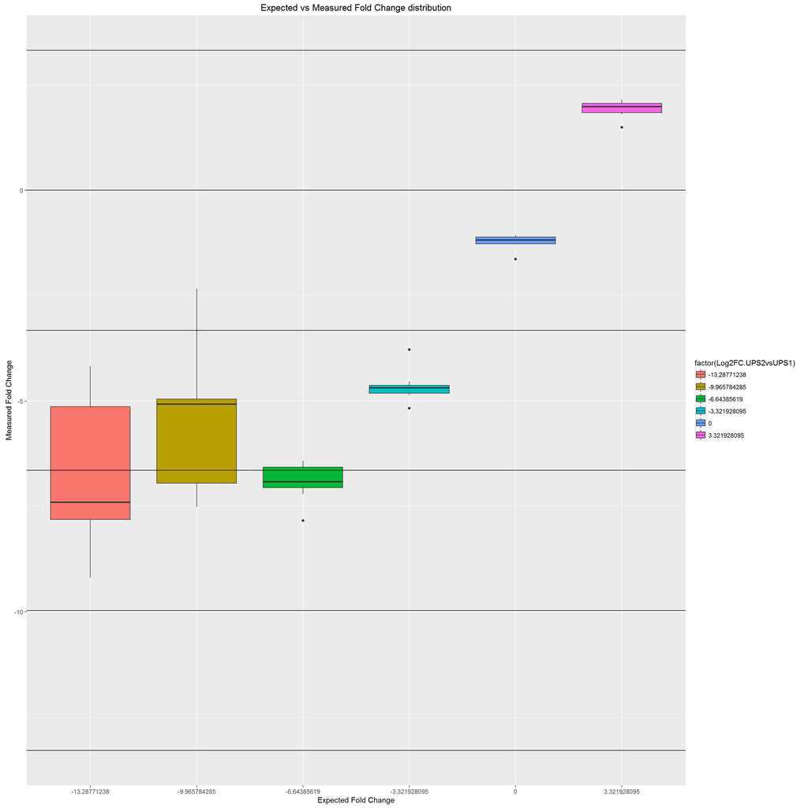

```r
b1 <- ggplot(subset(sigP, UPS=="UPS"), aes(factor(Log2FC.UPS2vsUPS1), log2FC))
b1 + geom_boxplot(aes(fill = factor(Log2FC.UPS2vsUPS1))) + geom_hline(yintercept=unique(sigP$Log2FC.UPS2vsUPS1)) +
  xlab("Expected Fold Change") + ylab("Measured Fold Change") + ggtitle("Expected vs Measured Fold Change distribution")
```

```r
#detach("package:Normalyzer", unload=TRUE)

# Loess normalization
pept_rawADJ <- read.delim("normalization_peptides/Log2-normalized.txt")

# remove peptides non-unique for groups or proteins, select Sequence, Proteins and Intensities columns, and melt table
mrawADJ <- melt(subset(pept_rawADJ, Unique..Groups. == "yes" & Unique..Proteins. == "yes", select=c(1,2,6:ncol(pept_rawADJ))), id.vars=1:2)

mrawADJ$value <- 2^mrawADJ$value
#pep2prot <- aggregate(mloG[,4], by=list(mloG$Protein, mloG$variable), function(x) sum(x, na.rm=TRUE))
#prots <- cast(pep2prot, Group.1 ~ Group.2, sum)
#colnames(pep.prot.melt) <- c("Leading.razor.protein", "SampleName", "Condition", "sumIntensity")

# add columns for MSstats
mrawADJ$PrecursorCharge <- 2
mrawADJ$FragmentIon <- NA
mrawADJ$ProductCharge <- NA
mrawADJ$IsotopeLabelType <- "L"
mrawADJ <- merge(mrawADJ, sampleInfo, by="variable",all=TRUE)

# Compare
mrawADJ_10col <- mrawADJ[,c(3,2,5:9,1,10,4)]
colnames(mrawADJ_10col) <- c("ProteinName", "PeptideSequence", "PrecursorCharge","FragmentIon", "ProductCharge","IsotopeLabelType", "Condition","BioReplicate", "Run", "Intensity")


quant_mrawADJ <- dataProcess(mrawADJ_10col, normalization=FALSE)
```

```
##
##   Summary of Features :
##                          count
## # of Protein              2046
## # of Peptides/Protein     1-85
## # of Transitions/Peptide   1-1
##
##   Summary of Samples :
##                            EcoUPS1 EcoUPS2
## # of MS runs                     4       4
## # of Biological Replicates       4       4
## # of Technical Replicates        1       1
```

```r
levels(quant_mrawADJ$ProcessedData$GROUP_ORIGINAL)
```

```
## [1] "EcoUPS1" "EcoUPS2"
```

```r
comparison<-matrix(c(-1,1),nrow=1)
row.names(comparison) <- "UPS2 vs UPS1"



#scopeOfTechReplication="expanded", scopeOfBioReplication="restricted",
comp_mrawADJ <- groupComparison(contrast.matrix=comparison, data=quant_mloG)

res_mrawADJ <- comp_mrawADJ$ComparisonResult
res_mrawADJ$threshold_1 = as.factor(abs(res_mrawADJ$log2FC) > 1 & res_mrawADJ$adj.pvalue < 0.01)
res_mrawADJ$threshold_2 = as.factor(abs(res_mrawADJ$log2FC) > 1 & res_mrawADJ$adj.pvalue < 0.05)
res_mrawADJ$threshold_3 = as.factor(abs(res_mrawADJ$log2FC) > 0.8  & res_mrawADJ$adj.pvalue < 0.05)
res_mrawADJ$UPS <- ifelse(grepl("_UPS$",res_mrawADJ$Protein), "UPS", "BKG")

spikes <- read.delim("spikes.txt")
res_mrawADJ$Protein2 <- gsub("\\|.*","", res_mrawADJ$Protein)
res_mrawADJ <- merge(res_mrawADJ, spikes, by.x="Protein2", by.y="Spike", all=TRUE)
res_mrawADJ$Log2FC.UPS2vsUPS1[is.na(res_mrawADJ$Log2FC.UPS2vsUPS1)] <- 0
res_mrawADJ$Ratio.UPS2vsUPS1[is.na(res_mrawADJ$Ratio.UPS2vsUPS1)] <- 1

res_mrawADJ$AbsErrorRatio <- (res_mrawADJ$Ratio.UPS2vsUPS1-(2^res_mrawADJ$Log2FC))/res_mrawADJ$Ratio.UPS2vsUPS1*100
```

```r
# Threshold 1
kable(table(res_mrawADJ$threshold_1, res_mrawADJ$UPS))
```

|  | BKG | UPS |
| --- | --- | --- |
| FALSE | 1986 | 10 |
| TRUE | 0 | 34 |

```r
# Threshold 2
kable(table(res_mrawADJ$threshold_2, res_mrawADJ$UPS))
```

|  | BKG | UPS |
| --- | --- | --- |
| FALSE | 1986 | 6 |
| TRUE | 0 | 38 |

```r
# Threshold 3
kable(table(res_mrawADJ$threshold_3, res_mrawADJ$UPS))
```

|  | BKG | UPS |
| --- | --- | --- |
| FALSE | 1984 | 6 |
| TRUE | 0 | 38 |

```r
# Export
#write.table(res_mrawADJ, file="MSstats_peptide_RAWADJ_UPS-Quant.txt", sep="\t", row.names=FALSE)
```

Volcano plot

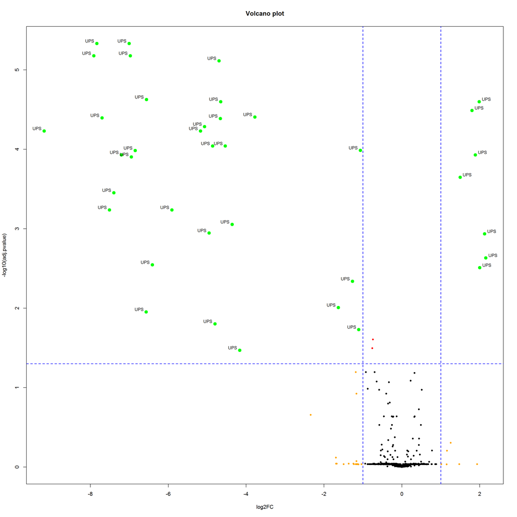

```r
with(res_mrawADJ, plot(log2FC, -log10(adj.pvalue), pch=20, main="Volcano plot"))
with(subset(res_mrawADJ, adj.pvalue < .05 ), points(log2FC, -log10(adj.pvalue), pch=20, col="red"))
with(subset(res_mrawADJ, abs(log2FC)>1), points(log2FC, -log10(adj.pvalue), pch=20, col="orange"))
with(subset(res_mrawADJ, adj.pvalue<.05 & abs(log2FC)>1), points(log2FC, cex=2, -log10(adj.pvalue), pch=20, col="green"))
with(subset(res_mrawADJ, adj.pvalue<.05 & abs(log2FC)>1), textxy(log2FC, -log10(adj.pvalue), labs=UPS, cex=.8))
abline(h = -log10(0.05), v = c(-1,1), col = "blue", lty =2, lwd = 1.5)
```

Table 1: Up- and Down-regulated proteins given a Log2FC > 1 or -1 and adj.pvalue below 0.05

```r
sigP <- (subset(res_mrawADJ, abs(log2FC) > 1 & adj.pvalue < 0.05))

sigP <- sigP[order(sigP$adj.pvalue),]

kable(sigP)
```

|  | Protein2 | Protein | Label | log2FC | SE | Tvalue | DF | pvalue | adj.pvalue | threshold_1 | threshold_2 | threshold_3 | UPS | Log2FC.UPS2vsUPS1 | Ratio.UPS2vsUPS1 | AbsErrorRatio |
| --- | --- | --- | --- | --- | --- | --- | --- | --- | --- | --- | --- | --- | --- | --- | --- | --- |
| 1999 | P01008ups | P01008ups\|ANT3_HUMAN_UPS | UPS2 vs UPS1 | -7.835158 | 0.1583618 | -49.476318 | 6 | 0.0000000 | 0.0000046 | TRUE | TRUE | TRUE | UPS | -6.643856 | 1e-02 | 0 |
| 2021 | P10599ups | P10599ups\|THIO_HUMAN_UPS | UPS2 vs UPS1 | -7.005182 | 0.1263875 | -55.426214 | 6 | 0.0000000 | 0.0000046 | TRUE | TRUE | TRUE | UPS | -6.643856 | 1e-02 | 0 |
| 2004 | P01344ups | P01344ups\|IGF2_HUMAN_UPS | UPS2 vs UPS1 | -6.977785 | 0.1019861 | -68.419007 | 5 | 0.0000000 | 0.0000066 | TRUE | TRUE | TRUE | UPS | -6.643856 | 1e-02 | 0 |
| 2014 | P05413ups | P05413ups\|FABPH_HUMAN_UPS | UPS2 vs UPS1 | -7.913276 | 0.1164699 | -67.942667 | 5 | 0.0000000 | 0.0000066 | TRUE | TRUE | TRUE | UPS | -13.287712 | 1e-04 | 0 |
| 2016 | P06732ups | P06732ups\|KCRM_HUMAN_UPS | UPS2 vs UPS1 | -4.698649 | 0.1204363 | -39.013562 | 6 | 0.0000000 | 0.0000077 | TRUE | TRUE | TRUE | UPS | -3.321928 | 1e-01 | 0 |
| 2028 | P55957ups | P55957ups\|BID_HUMAN_UPS | UPS2 vs UPS1 | -6.561084 | 0.2092121 | -31.360924 | 6 | 0.0000001 | 0.0000236 | TRUE | TRUE | TRUE | UPS | -6.643856 | 1e-02 | 0 |
| 2010 | P02768ups | P02768ups\|ALBU_HUMAN_UPS | UPS2 vs UPS1 | 1.985860 | 0.0667495 | 29.750924 | 6 | 0.0000001 | 0.0000250 | TRUE | TRUE | TRUE | UPS | 3.321928 | 1e+01 | 0 |
| 2023 | P12081ups | P12081ups\|SYHC_HUMAN_UPS | UPS2 vs UPS1 | -4.656332 | 0.1573898 | -29.584702 | 6 | 0.0000001 | 0.0000250 | TRUE | TRUE | TRUE | UPS | -3.321928 | 1e-01 | 0 |
| 1998 | P00918ups | P00918ups\|CAH2_HUMAN_UPS | UPS2 vs UPS1 | 1.798724 | 0.0647308 | 27.787752 | 6 | 0.0000001 | 0.0000323 | TRUE | TRUE | TRUE | UPS | 3.321928 | 1e+01 | 0 |
| 2009 | P02753ups | P02753ups\|RETBP_HUMAN_UPS | UPS2 vs UPS1 | -3.777470 | 0.1428204 | -26.449090 | 6 | 0.0000002 | 0.0000391 | TRUE | TRUE | TRUE | UPS | -3.321928 | 1e-01 | 0 |
| 2005 | P01375ups | P01375ups\|TNFA_HUMAN_UPS | UPS2 vs UPS1 | -7.702258 | 0.2972561 | -25.911186 | 6 | 0.0000002 | 0.0000401 | TRUE | TRUE | TRUE | UPS | -13.287712 | 1e-04 | 0 |
| 2025 | P16083ups | P16083ups\|NQO2_HUMAN_UPS | UPS2 vs UPS1 | -4.663880 | 0.1831952 | -25.458522 | 6 | 0.0000002 | 0.0000409 | TRUE | TRUE | TRUE | UPS | -3.321928 | 1e-01 | 0 |
| 2015 | P06396ups | P06396ups\|GELS_HUMAN_UPS | UPS2 vs UPS1 | -5.069076 | 0.2098658 | -24.153887 | 6 | 0.0000003 | 0.0000516 | TRUE | TRUE | TRUE | UPS | -9.965784 | 1e-03 | 0 |
| 2020 | P10145ups | P10145ups\|IL8_HUMAN_UPS | UPS2 vs UPS1 | -9.189667 | 0.0534267 | -172.005111 | 3 | 0.0000004 | 0.0000585 | TRUE | TRUE | TRUE | UPS | -13.287712 | 1e-04 | 0 |
| 2039 | Q15843ups | Q15843ups\|NEDD8_HUMAN_UPS | UPS2 vs UPS1 | -5.173060 | 0.2229361 | -23.204226 | 6 | 0.0000004 | 0.0000585 | TRUE | TRUE | TRUE | UPS | -3.321928 | 1e-01 | 0 |
| 2029 | P61626ups | P61626ups\|LYSC_HUMAN_UPS | UPS2 vs UPS1 | -4.860515 | 0.2315479 | -20.991407 | 6 | 0.0000008 | 0.0000907 | TRUE | TRUE | TRUE | UPS | -3.321928 | 1e-01 | 0 |
| 2034 | P63279ups | P63279ups\|UBC9_HUMAN_UPS | UPS2 vs UPS1 | -4.535738 | 0.2146964 | -21.126289 | 6 | 0.0000007 | 0.0000907 | TRUE | TRUE | TRUE | UPS | -3.321928 | 1e-01 | 0 |
| 2013 | P04040ups | P04040ups\|CATA_HUMAN_UPS | UPS2 vs UPS1 | -1.065829 | 0.0523615 | -20.355179 | 6 | 0.0000009 | 0.0001029 | TRUE | TRUE | TRUE | UPS | 0.000000 | 1e+00 | 0 |
| 2017 | P08263ups | P08263ups\|GSTA1_HUMAN_UPS | UPS2 vs UPS1 | -6.850460 | 0.3399047 | -20.154061 | 6 | 0.0000010 | 0.0001033 | TRUE | TRUE | TRUE | UPS | -6.643856 | 1e-02 | 0 |
| 2002 | P01127ups | P01127ups\|PDGFB_HUMAN_UPS | UPS2 vs UPS1 | -7.206180 | 0.2628337 | -27.417260 | 5 | 0.0000012 | 0.0001174 | TRUE | TRUE | TRUE | UPS | -6.643856 | 1e-02 | 0 |
| 2032 | P62988ups | P62988ups\|UBIQ_HUMAN_UPS | UPS2 vs UPS1 | 1.886859 | 0.0972974 | 19.392704 | 6 | 0.0000012 | 0.0001174 | TRUE | TRUE | TRUE | UPS | 3.321928 | 1e+01 | 0 |
| 2011 | P02787ups | P02787ups\|TRFE_HUMAN_UPS | UPS2 vs UPS1 | -6.948676 | 0.0589726 | -117.828868 | 3 | 0.0000013 | 0.0001241 | TRUE | TRUE | TRUE | UPS | -9.965784 | 1e-03 | 0 |
| 2035 | P68871ups | P68871ups\|HBB_HUMAN_UPS | UPS2 vs UPS1 | 1.495520 | 0.0874105 | 17.109157 | 6 | 0.0000026 | 0.0002248 | TRUE | TRUE | TRUE | UPS | 3.321928 | 1e+01 | 0 |
| 2018 | P08758ups | P08758ups\|ANXA5_HUMAN_UPS | UPS2 vs UPS1 | -7.400841 | 0.4703048 | -15.736265 | 6 | 0.0000042 | 0.0003524 | TRUE | TRUE | TRUE | UPS | -13.287712 | 1e-04 | 0 |
| 2012 | P02788ups | P02788ups\|TRFL_HUMAN_UPS | UPS2 vs UPS1 | -5.907576 | 0.4142241 | -14.261789 | 6 | 0.0000074 | 0.0005797 | TRUE | TRUE | TRUE | UPS | -13.287712 | 1e-04 | 0 |
| 2037 | P99999ups | P99999ups\|CYC_HUMAN_UPS | UPS2 vs UPS1 | -7.511379 | 0.2511204 | -29.911461 | 4 | 0.0000074 | 0.0005797 | TRUE | TRUE | TRUE | UPS | -9.965784 | 1e-03 | 0 |
| 2022 | P10636-8ups | P10636-8ups\|TAU_HUMAN_UPS | UPS2 vs UPS1 | -4.359706 | 0.3306039 | -13.187100 | 6 | 0.0000117 | 0.0008810 | TRUE | TRUE | TRUE | UPS | -13.287712 | 1e-04 | 0 |
| 1992 | O00762ups | O00762ups\|UBE2C_HUMAN_UPS | UPS2 vs UPS1 | -4.953190 | 0.3944550 | -12.557046 | 6 | 0.0000156 | 0.0011294 | TRUE | TRUE | TRUE | UPS | -9.965784 | 1e-03 | 0 |
| 1997 | P00915ups | P00915ups\|CAH1_HUMAN_UPS | UPS2 vs UPS1 | 2.126234 | 0.1710793 | 12.428351 | 6 | 0.0000166 | 0.0011577 | TRUE | TRUE | TRUE | UPS | 3.321928 | 1e+01 | 0 |
| 2026 | P41159ups | P41159ups\|LEP_HUMAN_UPS | UPS2 vs UPS1 | 2.154100 | 0.1966993 | 10.951237 | 6 | 0.0000344 | 0.0023246 | TRUE | TRUE | TRUE | UPS | 3.321928 | 1e+01 | 0 |
| 1993 | O76070ups | O76070ups\|SYUG_HUMAN_UPS | UPS2 vs UPS1 | -6.409036 | 0.6092476 | -10.519592 | 6 | 0.0000434 | 0.0028337 | TRUE | TRUE | TRUE | UPS | -6.643856 | 1e-02 | 0 |
| 2036 | P69905ups | P69905ups\|HBA_HUMAN_UPS | UPS2 vs UPS1 | 1.998815 | 0.1938465 | 10.311328 | 6 | 0.0000486 | 0.0030781 | TRUE | TRUE | TRUE | UPS | 3.321928 | 1e+01 | 0 |
| 2024 | P15559ups | P15559ups\|NQO1_HUMAN_UPS | UPS2 vs UPS1 | -1.271416 | 0.1329214 | -9.565172 | 6 | 0.0000746 | 0.0045793 | TRUE | TRUE | TRUE | UPS | 0.000000 | 1e+00 | 0 |
| 2007 | P02144ups | P02144ups\|MYG_HUMAN_UPS | UPS2 vs UPS1 | -1.631103 | 0.1961678 | -8.314837 | 6 | 0.0001641 | 0.0097806 | TRUE | TRUE | TRUE | UPS | 0.000000 | 1e+00 | 0 |
| 2030 | P61769ups | P61769ups\|B2MG_HUMAN_UPS | UPS2 vs UPS1 | -6.567643 | 0.6731790 | -9.756161 | 5 | 0.0001924 | 0.0111377 | FALSE | TRUE | TRUE | UPS | -6.643856 | 1e-02 | 0 |
| 1996 | P00709ups | P00709ups\|LALBA_HUMAN_UPS | UPS2 vs UPS1 | -4.799668 | 0.6352164 | -7.555958 | 6 | 0.0002789 | 0.0156978 | FALSE | TRUE | TRUE | UPS | -3.321928 | 1e-01 | 0 |
| 2033 | P63165ups | P63165ups\|SUMO1_HUMAN_UPS | UPS2 vs UPS1 | -1.107250 | 0.1518415 | -7.292139 | 6 | 0.0003389 | 0.0185595 | FALSE | TRUE | TRUE | UPS | 0.000000 | 1e+00 | 0 |
| 1995 | P00441ups | P00441ups\|SODC_HUMAN_UPS | UPS2 vs UPS1 | -4.165118 | 0.2812038 | -14.811740 | 3 | 0.0006677 | 0.0338182 | FALSE | TRUE | TRUE | UPS | -13.287712 | 1e-04 | 0 |

Plot Measured against Expected Log2 FC for the significant proteins

```r
with(res_mrawADJ, plot(log2FC, Log2FC.UPS2vsUPS1, pch=1))
with(subset(res_mrawADJ, UPS == "UPS" ), points(log2FC, Log2FC.UPS2vsUPS1, pch=20, col="red"))
```

[output not shown]

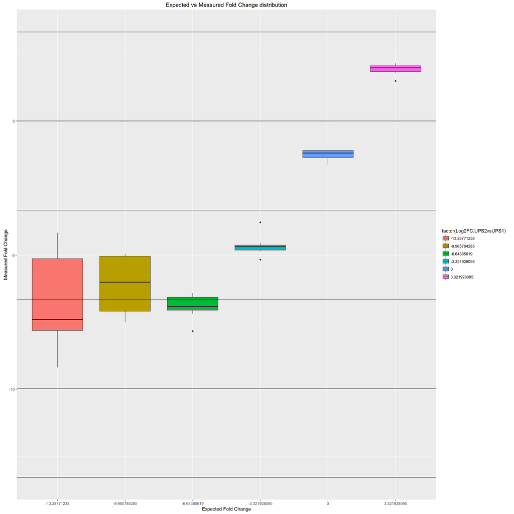

```r
b1 <- ggplot(subset(sigP, UPS=="UPS"), aes(factor(Log2FC.UPS2vsUPS1), log2FC))
b1 + geom_boxplot(aes(fill = factor(Log2FC.UPS2vsUPS1))) + geom_hline(yintercept=unique(sigP$Log2FC.UPS2vsUPS1)) +
  xlab("Expected Fold Change") + ylab("Measured Fold Change") + ggtitle("Expected vs Measured Fold Change distribution")
```

## Statistical test (MSstats) for differential protein abundance. VSN-G Normalized

```r
#detach("package:Normalyzer", unload=TRUE)

# Loess normalization
pept_VSN <- read.delim("normalization_peptides/VSN-G-normalized.txt")

# remove peptides non-unique for groups or proteins, select Sequence, Proteins and Intensities columns, and melt table
mVSN <- melt(subset(pept_VSN, Unique..Groups. == "yes" & Unique..Proteins. == "yes", select=c(1,2,6:ncol(pept_VSN))), id.vars=1:2)
mVSN$value <- 2^mVSN$value

#pep2prot <- aggregate(mVSN[,4], by=list(mVSN$Protein, mVSN$variable), function(x) sum(x, na.rm=TRUE))
#prots <- cast(pep2prot, Group.1 ~ Group.2, sum)
#colnames(pep.prot.melt) <- c("Leading.razor.protein", "SampleName", "Condition", "sumIntensity")

# add columns for MSstats
mVSN$PrecursorCharge <- 2
mVSN$FragmentIon <- NA
mVSN$ProductCharge <- NA
mVSN$IsotopeLabelType <- "L"
mVSN <- merge(mVSN, sampleInfo, by="variable",all=TRUE)

# Compare
mVSN_10col <- mVSN[,c(3,2,5:9,1,10,4)]
colnames(mVSN_10col) <- c("ProteinName", "PeptideSequence", "PrecursorCharge","FragmentIon", "ProductCharge","IsotopeLabelType", "Condition","BioReplicate", "Run", "Intensity")


quant_mVSN <- dataProcess(mVSN_10col, normalization=FALSE)
```

```
##
##   Summary of Features :
##                          count
## # of Protein              2046
## # of Peptides/Protein     1-85
## # of Transitions/Peptide   1-1
##
##   Summary of Samples :
##                            EcoUPS1 EcoUPS2
## # of MS runs                     4       4
## # of Biological Replicates       4       4
## # of Technical Replicates        1       1
```

```r
levels(quant_mVSN$ProcessedData$GROUP_ORIGINAL)
```

```
## [1] "EcoUPS1" "EcoUPS2"
```

```r
comparison<-matrix(c(-1,1),nrow=1)
row.names(comparison) <- "UPS2 vs UPS1"


#scopeOfTechReplication="expanded", scopeOfBioReplication="restricted",
comp_mVSN <- groupComparison(contrast.matrix=comparison, data=quant_mVSN)

res_mVSN <- comp_mVSN$ComparisonResult
res_mVSN$threshold_1 = as.factor(abs(res_mVSN$log2FC) > 1 & res_mVSN$adj.pvalue < 0.01)
res_mVSN$threshold_2 = as.factor(abs(res_mVSN$log2FC) > 1 & res_mVSN$adj.pvalue < 0.05)
res_mVSN$threshold_3 = as.factor(abs(res_mVSN$log2FC) > 0.8  & res_mVSN$adj.pvalue < 0.05)
res_mVSN$UPS <- ifelse(grepl("_UPS$",res_mVSN$Protein), "UPS", "BKG")

spikes <- read.delim("spikes.txt")
res_mVSN$Protein2 <- gsub("\\|.*","", res_mVSN$Protein)
res_mVSN <- merge(res_mVSN, spikes, by.x="Protein2", by.y="Spike", all=TRUE)
res_mVSN$Log2FC.UPS2vsUPS1[is.na(res_mVSN$Log2FC.UPS2vsUPS1)] <- 0
res_mVSN$Ratio.UPS2vsUPS1[is.na(res_mVSN$Ratio.UPS2vsUPS1)] <- 1

res_mVSN$AbsErrorRatio <- (res_mVSN$Ratio.UPS2vsUPS1-(2^res_mVSN$log2FC))/res_mVSN$Ratio.UPS2vsUPS1*100
```

```r
# Threshold 1
kable(table(res_mVSN$threshold_1, res_mVSN$UPS))
```

|  | BKG | UPS |
| --- | --- | --- |
| FALSE | 1985 | 12 |
| TRUE | 0 | 32 |

```r
# Threshold 2
kable(table(res_mVSN$threshold_2, res_mVSN$UPS))
```

|  | BKG | UPS |
| --- | --- | --- |
| FALSE | 1985 | 6 |
| TRUE | 0 | 38 |

```r
# Threshold 3
kable(table(res_mVSN$threshold_3, res_mVSN$UPS))
```

|  | BKG | UPS |
| --- | --- | --- |
| FALSE | 1984 | 6 |
| TRUE | 0 | 38 |

```r
# Export
#write.table(res_mVSN, file="MSstats_peptide_VSN_UPS-Quant.txt", sep="\t", row.names=FALSE)
```

Volcano plot

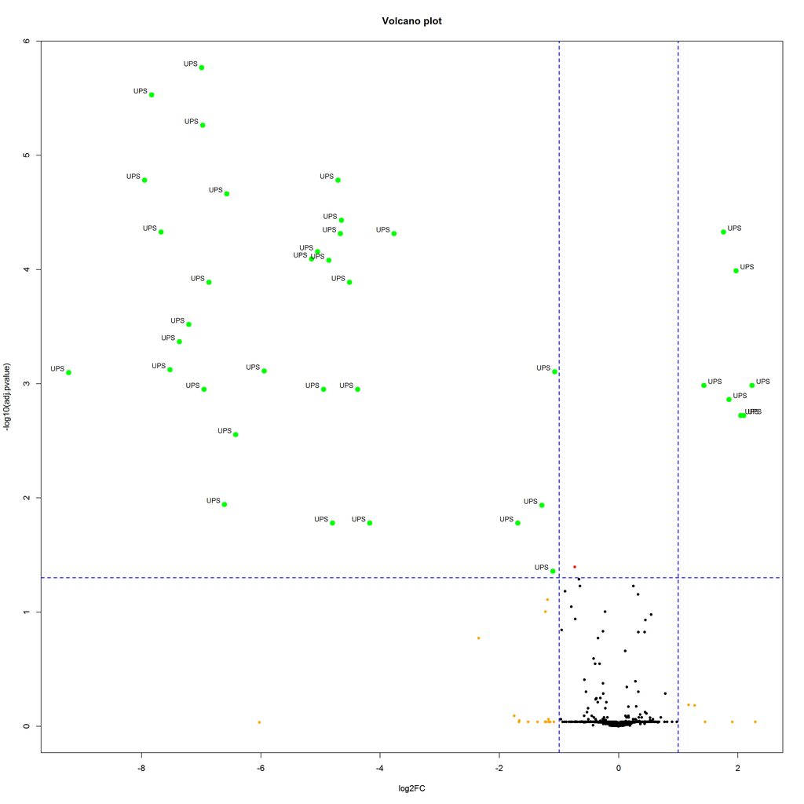

```r
with(res_mVSN, plot(log2FC, -log10(adj.pvalue), pch=20, main="Volcano plot"))
with(subset(res_mVSN, adj.pvalue < .05 ), points(log2FC, -log10(adj.pvalue), pch=20, col="red"))
with(subset(res_mVSN, abs(log2FC)>1), points(log2FC, -log10(adj.pvalue), pch=20, col="orange"))
with(subset(res_mVSN, adj.pvalue<.05 & abs(log2FC)>1), points(log2FC, cex=2, -log10(adj.pvalue), pch=20, col="green"))
with(subset(res_mVSN, adj.pvalue<.05 & abs(log2FC)>1), textxy(log2FC, -log10(adj.pvalue), labs=UPS, cex=.8))
abline(h = -log10(0.05), v = c(-1,1), col = "blue", lty =2, lwd = 1.5)
```

Table 1: Up- and Down-regulated proteins given a Log2FC > 1 or -1 and adj.pvalue below 0.05

```r
sigP <- (subset(res_mVSN, abs(log2FC) > 1 & adj.pvalue < 0.05))

sigP <- sigP[order(sigP$adj.pvalue),]

kable(sigP)
```

|  | Protein2 | Protein | Label | log2FC | SE | Tvalue | DF | pvalue | adj.pvalue | threshold_1 | threshold_2 | threshold_3 | UPS | Log2FC.UPS2vsUPS1 | Ratio.UPS2vsUPS1 | AbsErrorRatio |
| --- | --- | --- | --- | --- | --- | --- | --- | --- | --- | --- | --- | --- | --- | --- | --- | --- |
| 2021 | P10599ups | P10599ups\|THIO_HUMAN_UPS | UPS2 vs UPS1 | -6.994604 | 0.1065182 | -65.665787 | 6 | 0.0000000 | 0.0000017 | TRUE | TRUE | TRUE | UPS | -6.643856 | 1e-02 | 21.582242 |
| 1999 | P01008ups | P01008ups\|ANT3_HUMAN_UPS | UPS2 vs UPS1 | -7.834147 | 0.1468380 | -53.352326 | 6 | 0.0000000 | 0.0000029 | TRUE | TRUE | TRUE | UPS | -6.643856 | 1e-02 | 56.178558 |
| 2004 | P01344ups | P01344ups\|IGF2_HUMAN_UPS | UPS2 vs UPS1 | -6.979552 | 0.0932523 | -74.845938 | 5 | 0.0000000 | 0.0000054 | TRUE | TRUE | TRUE | UPS | -6.643856 | 1e-02 | 20.759821 |
| 2014 | P05413ups | P05413ups\|FABPH_HUMAN_UPS | UPS2 vs UPS1 | -7.952387 | 0.1412892 | -56.284479 | 5 | 0.0000000 | 0.0000164 | TRUE | TRUE | TRUE | UPS | -13.287712 | 1e-04 | -3937.318706 |
| 2016 | P06732ups | P06732ups\|KCRM_HUMAN_UPS | UPS2 vs UPS1 | -4.711041 | 0.1371618 | -34.346587 | 6 | 0.0000000 | 0.0000164 | TRUE | TRUE | TRUE | UPS | -3.321928 | 1e-01 | 61.820037 |
| 2028 | P55957ups | P55957ups\|BID_HUMAN_UPS | UPS2 vs UPS1 | -6.573012 | 0.2066239 | -31.811477 | 6 | 0.0000001 | 0.0000217 | TRUE | TRUE | TRUE | UPS | -6.643856 | 1e-02 | -5.033075 |
| 2023 | P12081ups | P12081ups\|SYHC_HUMAN_UPS | UPS2 vs UPS1 | -4.653136 | 0.1640855 | -28.358003 | 6 | 0.0000001 | 0.0000368 | TRUE | TRUE | TRUE | UPS | -3.321928 | 1e-01 | 60.256464 |
| 1998 | P00918ups | P00918ups\|CAH2_HUMAN_UPS | UPS2 vs UPS1 | 1.756847 | 0.0661463 | 26.560009 | 6 | 0.0000002 | 0.0000467 | TRUE | TRUE | TRUE | UPS | 3.321928 | 1e+01 | 66.204125 |
| 2005 | P01375ups | P01375ups\|TNFA_HUMAN_UPS | UPS2 vs UPS1 | -7.677078 | 0.2938737 | -26.123735 | 6 | 0.0000002 | 0.0000467 | TRUE | TRUE | TRUE | UPS | -13.287712 | 1e-04 | -4786.178504 |
| 2009 | P02753ups | P02753ups\|RETBP_HUMAN_UPS | UPS2 vs UPS1 | -3.767364 | 0.1499697 | -25.120834 | 6 | 0.0000003 | 0.0000483 | TRUE | TRUE | TRUE | UPS | -3.321928 | 1e-01 | 26.563743 |
| 2025 | P16083ups | P16083ups\|NQO2_HUMAN_UPS | UPS2 vs UPS1 | -4.667495 | 0.1851000 | -25.216069 | 6 | 0.0000003 | 0.0000483 | TRUE | TRUE | TRUE | UPS | -3.321928 | 1e-01 | 60.650060 |
| 2015 | P06396ups | P06396ups\|GELS_HUMAN_UPS | UPS2 vs UPS1 | -5.051821 | 0.2169210 | -23.288756 | 6 | 0.0000004 | 0.0000694 | TRUE | TRUE | TRUE | UPS | -9.965784 | 1e-03 | -2914.743592 |
| 2039 | Q15843ups | Q15843ups\|NEDD8_HUMAN_UPS | UPS2 vs UPS1 | -5.150974 | 0.2299129 | -22.404024 | 6 | 0.0000005 | 0.0000806 | TRUE | TRUE | TRUE | UPS | -3.321928 | 1e-01 | 71.854938 |
| 2029 | P61626ups | P61626ups\|LYSC_HUMAN_UPS | UPS2 vs UPS1 | -4.861716 | 0.2207046 | -22.028153 | 6 | 0.0000006 | 0.0000828 | TRUE | TRUE | TRUE | UPS | -3.321928 | 1e-01 | 65.606393 |
| 2010 | P02768ups | P02768ups\|ALBU_HUMAN_UPS | UPS2 vs UPS1 | 1.968855 | 0.0937108 | 21.009902 | 6 | 0.0000008 | 0.0001023 | TRUE | TRUE | TRUE | UPS | 3.321928 | 1e+01 | 60.854265 |
| 2017 | P08263ups | P08263ups\|GSTA1_HUMAN_UPS | UPS2 vs UPS1 | -6.873909 | 0.3474307 | -19.784979 | 6 | 0.0000011 | 0.0001289 | TRUE | TRUE | TRUE | UPS | -6.643856 | 1e-02 | 14.739615 |
| 2034 | P63279ups | P63279ups\|UBC9_HUMAN_UPS | UPS2 vs UPS1 | -4.514331 | 0.2279431 | -19.804642 | 6 | 0.0000011 | 0.0001289 | TRUE | TRUE | TRUE | UPS | -3.321928 | 1e-01 | 56.242648 |
| 2002 | P01127ups | P01127ups\|PDGFB_HUMAN_UPS | UPS2 vs UPS1 | -7.210275 | 0.3086389 | -23.361522 | 5 | 0.0000027 | 0.0003011 | TRUE | TRUE | TRUE | UPS | -6.643856 | 1e-02 | 32.470921 |
| 2018 | P08758ups | P08758ups\|ANXA5_HUMAN_UPS | UPS2 vs UPS1 | -7.371774 | 0.4653010 | -15.843023 | 6 | 0.0000040 | 0.0004278 | TRUE | TRUE | TRUE | UPS | -13.287712 | 1e-04 | -5937.747955 |
| 2037 | P99999ups | P99999ups\|CYC_HUMAN_UPS | UPS2 vs UPS1 | -7.529326 | 0.2514247 | -29.946649 | 4 | 0.0000074 | 0.0007501 | TRUE | TRUE | TRUE | UPS | -9.965784 | 1e-03 | -441.311045 |
| 2012 | P02788ups | P02788ups\|TRFL_HUMAN_UPS | UPS2 vs UPS1 | -5.946404 | 0.4221785 | -14.085045 | 6 | 0.0000080 | 0.0007712 | TRUE | TRUE | TRUE | UPS | -13.287712 | 1e-04 | -16116.389288 |
| 2013 | P04040ups | P04040ups\|CATA_HUMAN_UPS | UPS2 vs UPS1 | -1.074020 | 0.0770862 | -13.932726 | 6 | 0.0000085 | 0.0007845 | TRUE | TRUE | TRUE | UPS | 0.000000 | 1e+00 | 52.500649 |
| 2020 | P10145ups | P10145ups\|IL8_HUMAN_UPS | UPS2 vs UPS1 | -9.227378 | 0.1477003 | -62.473640 | 3 | 0.0000090 | 0.0007960 | TRUE | TRUE | TRUE | UPS | -13.287712 | 1e-04 | -1568.332138 |
| 2026 | P41159ups | P41159ups\|LEP_HUMAN_UPS | UPS2 vs UPS1 | 2.239095 | 0.1715242 | 13.054106 | 6 | 0.0000125 | 0.0010322 | TRUE | TRUE | TRUE | UPS | 3.321928 | 1e+01 | 52.789917 |
| 2035 | P68871ups | P68871ups\|HBB_HUMAN_UPS | UPS2 vs UPS1 | 1.430636 | 0.1100138 | 13.004150 | 6 | 0.0000127 | 0.0010322 | TRUE | TRUE | TRUE | UPS | 3.321928 | 1e+01 | 73.043441 |
| 1992 | O00762ups | O00762ups\|UBE2C_HUMAN_UPS | UPS2 vs UPS1 | -4.951192 | 0.3934735 | -12.583294 | 6 | 0.0000154 | 0.0011158 | TRUE | TRUE | TRUE | UPS | -9.965784 | 1e-03 | -3132.530654 |
| 2011 | P02787ups | P02787ups\|TRFE_HUMAN_UPS | UPS2 vs UPS1 | -6.957492 | 0.1327615 | -52.405929 | 3 | 0.0000153 | 0.0011158 | TRUE | TRUE | TRUE | UPS | -9.965784 | 1e-03 | -704.611276 |
| 2022 | P10636-8ups | P10636-8ups\|TAU_HUMAN_UPS | UPS2 vs UPS1 | -4.378332 | 0.3476668 | -12.593469 | 6 | 0.0000153 | 0.0011158 | TRUE | TRUE | TRUE | UPS | -13.287712 | 1e-04 | -47982.922422 |
| 2032 | P62988ups | P62988ups\|UBIQ_HUMAN_UPS | UPS2 vs UPS1 | 1.848947 | 0.1531946 | 12.069270 | 6 | 0.0000196 | 0.0013722 | TRUE | TRUE | TRUE | UPS | 3.321928 | 1e+01 | 63.976275 |
| 1997 | P00915ups | P00915ups\|CAH1_HUMAN_UPS | UPS2 vs UPS1 | 2.096914 | 0.1857709 | 11.287635 | 6 | 0.0000289 | 0.0018901 | TRUE | TRUE | TRUE | UPS | 3.321928 | 1e+01 | 57.220673 |
| 2036 | P69905ups | P69905ups\|HBA_HUMAN_UPS | UPS2 vs UPS1 | 2.048722 | 0.1810828 | 11.313731 | 6 | 0.0000285 | 0.0018901 | TRUE | TRUE | TRUE | UPS | 3.321928 | 1e+01 | 58.626058 |
| 1993 | O76070ups | O76070ups\|SYUG_HUMAN_UPS | UPS2 vs UPS1 | -6.423668 | 0.6118866 | -10.498135 | 6 | 0.0000439 | 0.0027775 | TRUE | TRUE | TRUE | UPS | -6.643856 | 1e-02 | -16.488545 |
| 2030 | P61769ups | P61769ups\|B2MG_HUMAN_UPS | UPS2 vs UPS1 | -6.612707 | 0.6729082 | -9.827057 | 5 | 0.0001859 | 0.0114103 | FALSE | TRUE | TRUE | UPS | -6.643856 | 1e-02 | -2.182561 |
| 2024 | P15559ups | P15559ups\|NQO1_HUMAN_UPS | UPS2 vs UPS1 | -1.290102 | 0.1599608 | -8.065111 | 6 | 0.0001945 | 0.0115905 | FALSE | TRUE | TRUE | UPS | 0.000000 | 1e+00 | 59.107782 |
| 1995 | P00441ups | P00441ups\|SODC_HUMAN_UPS | UPS2 vs UPS1 | -4.175818 | 0.2123015 | -19.669276 | 3 | 0.0002871 | 0.0165453 | FALSE | TRUE | TRUE | UPS | -13.287712 | 1e-04 | -55229.100427 |
| 1996 | P00709ups | P00709ups\|LALBA_HUMAN_UPS | UPS2 vs UPS1 | -4.801787 | 0.6436470 | -7.460280 | 6 | 0.0002992 | 0.0165453 | FALSE | TRUE | TRUE | UPS | -3.321928 | 1e-01 | 64.147611 |
| 2007 | P02144ups | P02144ups\|MYG_HUMAN_UPS | UPS2 vs UPS1 | -1.691026 | 0.2270831 | -7.446729 | 6 | 0.0003022 | 0.0165453 | FALSE | TRUE | TRUE | UPS | 0.000000 | 1e+00 | 69.029348 |
| 2033 | P63165ups | P63165ups\|SUMO1_HUMAN_UPS | UPS2 vs UPS1 | -1.104752 | 0.1794135 | -6.157578 | 6 | 0.0008415 | 0.0437151 | FALSE | TRUE | TRUE | UPS | 0.000000 | 1e+00 | 53.501773 |

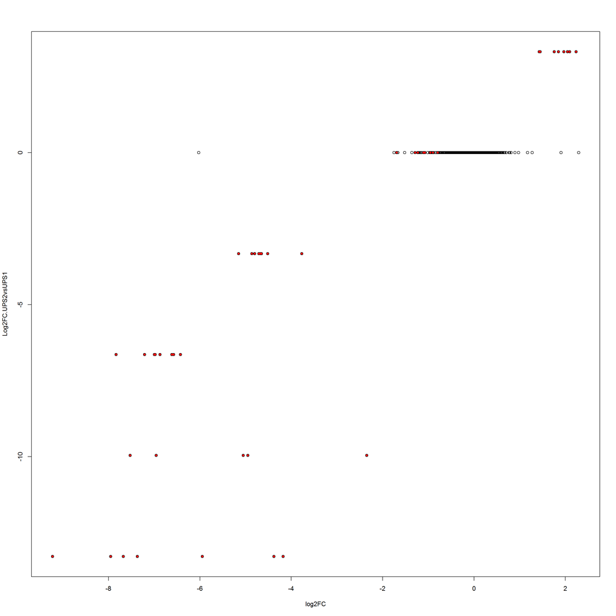

```r
with(res_mVSN, plot(log2FC, Log2FC.UPS2vsUPS1, pch=1))
with(subset(res_mVSN, UPS == "UPS" ), points(log2FC, Log2FC.UPS2vsUPS1, pch=20, col="red"))
```

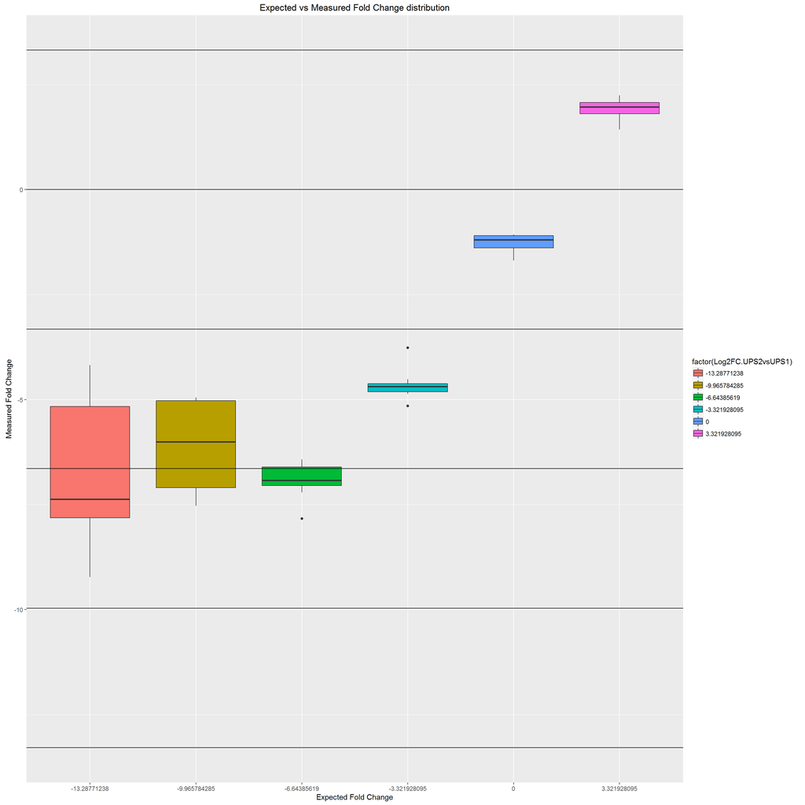

```r
b1 <- ggplot(subset(sigP, UPS=="UPS"), aes(factor(Log2FC.UPS2vsUPS1), log2FC))
b1 + geom_boxplot(aes(fill = factor(Log2FC.UPS2vsUPS1))) + geom_hline(yintercept=unique(sigP$Log2FC.UPS2vsUPS1)) +
  xlab("Expected Fold Change") + ylab("Measured Fold Change") + ggtitle("Expected vs Measured Fold Change distribution")
```

## Statistical test (MSstats) for differential protein abundance. RLR-G Normalized

```r
#detach("package:Normalyzer", unload=TRUE)

# Loess normalization
pept_RLR <- read.delim("normalization_peptides/RLR-G-normalized.txt")

# remove peptides non-unique for groups or proteins, select Sequence, Proteins and Intensities columns, and melt table
mRLR <- melt(subset(pept_RLR, Unique..Groups. == "yes" & Unique..Proteins. == "yes", select=c(1,2,6:ncol(pept_RLR))), id.vars=1:2)
mRLR$value <- 2^mRLR$value

#pep2prot <- aggregate(mRLR[,4], by=list(mRLR$Protein, mRLR$variable), function(x) sum(x, na.rm=TRUE))
#prots <- cast(pep2prot, Group.1 ~ Group.2, sum)
#colnames(pep.prot.melt) <- c("Leading.razor.protein", "SampleName", "Condition", "sumIntensity")

# add columns for MSstats
mRLR$PrecursorCharge <- 2
mRLR$FragmentIon <- NA
mRLR$ProductCharge <- NA
mRLR$IsotopeLabelType <- "L"
mRLR <- merge(mRLR, sampleInfo, by="variable",all=TRUE)

# Compare
mRLR_10col <- mRLR[,c(3,2,5:9,1,10,4)]
colnames(mRLR_10col) <- c("ProteinName", "PeptideSequence", "PrecursorCharge","FragmentIon", "ProductCharge","IsotopeLabelType", "Condition","BioReplicate", "Run", "Intensity")


quant_mRLR <- dataProcess(mRLR_10col, normalization=FALSE)
```

```
##
##   Summary of Features :
##                          count
## # of Protein              2046
## # of Peptides/Protein     1-85
## # of Transitions/Peptide   1-1
##
##   Summary of Samples :
##                            EcoUPS1 EcoUPS2
## # of MS runs                     4       4
## # of Biological Replicates       4       4
## # of Technical Replicates        1       1
```

```r
levels(quant_mRLR$ProcessedData$GROUP_ORIGINAL)
```

```
## [1] "EcoUPS1" "EcoUPS2"
```

```r
comparison<-matrix(c(-1,1),nrow=1)
row.names(comparison) <- "UPS2 vs UPS1"



#scopeOfTechReplication="expanded", scopeOfBioReplication="restricted",
comp_mRLR <- groupComparison(contrast.matrix=comparison, data=quant_mRLR)

res_mRLR <- comp_mRLR$ComparisonResult
res_mRLR$threshold_1 = as.factor(abs(res_mRLR$log2FC) > 1 & res_mRLR$adj.pvalue < 0.01)
res_mRLR$threshold_2 = as.factor(abs(res_mRLR$log2FC) > 1 & res_mRLR$adj.pvalue < 0.05)
res_mRLR$threshold_3 = as.factor(abs(res_mRLR$log2FC) > 0.8  & res_mRLR$adj.pvalue < 0.05)
res_mRLR$UPS <- ifelse(grepl("_UPS$",res_mRLR$Protein), "UPS", "BKG")

spikes <- read.delim("spikes.txt")
res_mRLR$Protein2 <- gsub("\\|.*","", res_mRLR$Protein)
res_mRLR <- merge(res_mRLR, spikes, by.x="Protein2", by.y="Spike", all=TRUE)
res_mRLR$Log2FC.UPS2vsUPS1[is.na(res_mRLR$Log2FC.UPS2vsUPS1)] <- 0
res_mRLR$Ratio.UPS2vsUPS1[is.na(res_mRLR$Ratio.UPS2vsUPS1)] <- 1

res_mRLR$AbsErrorRatio <- (res_mRLR$Ratio.UPS2vsUPS1-(2^res_mRLR$log2FC))/res_mRLR$Ratio.UPS2vsUPS1*100
```

```r
# Threshold 1
kable(table(res_mRLR$threshold_1, res_mRLR$UPS))
```

|  | BKG | UPS |
| --- | --- | --- |
| FALSE | 1986 | 11 |
| TRUE | 0 | 33 |

```r
# Threshold 2
kable(table(res_mRLR$threshold_2, res_mRLR$UPS))
```

|  | BKG | UPS |
| --- | --- | --- |
| FALSE | 1986 | 6 |
| TRUE | 0 | 38 |

```r
# Threshold 3
kable(table(res_mRLR$threshold_3, res_mRLR$UPS))
```

|  | BKG | UPS |
| --- | --- | --- |
| FALSE | 1984 | 6 |
| TRUE | 0 | 38 |

```r
# Export
#write.table(res_mRLR, file="MSstats_peptide_RawADJ_UPS-Quant.txt", sep="\t", row.names=FALSE)
```

Volcano plot

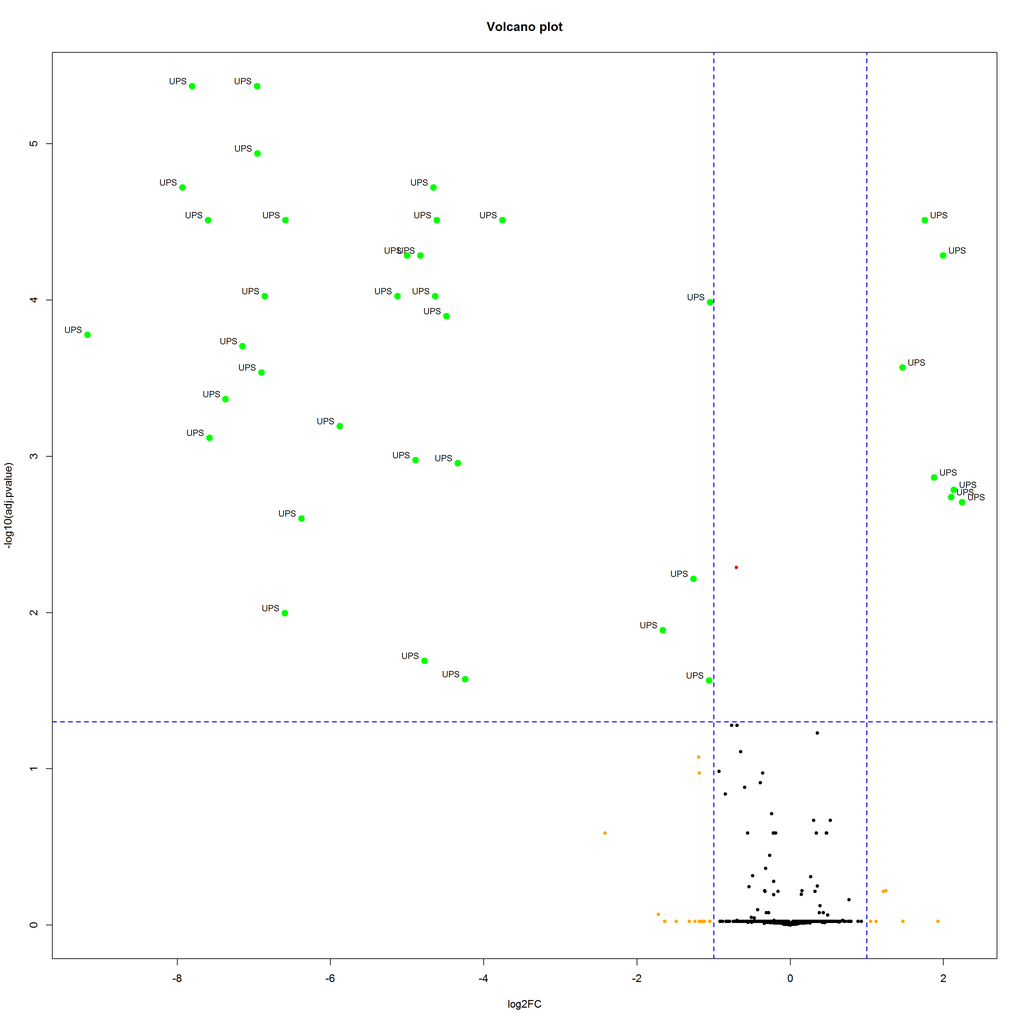

```r
with(res_mRLR, plot(log2FC, -log10(adj.pvalue), pch=20, main="Volcano plot"))
with(subset(res_mRLR, adj.pvalue < .05 ), points(log2FC, -log10(adj.pvalue), pch=20, col="red"))
with(subset(res_mRLR, abs(log2FC)>1), points(log2FC, -log10(adj.pvalue), pch=20, col="orange"))
with(subset(res_mRLR, adj.pvalue<.05 & abs(log2FC)>1), points(log2FC, cex=2, -log10(adj.pvalue), pch=20, col="green"))
with(subset(res_mRLR, adj.pvalue<.05 & abs(log2FC)>1), textxy(log2FC, -log10(adj.pvalue), labs=UPS, cex=.8))
abline(h = -log10(0.05), v = c(-1,1), col = "blue", lty =2, lwd = 1.5)
```

Table 1: Up- and Down-regulated proteins given a Log2FC > 1 or -1 and adj.pvalue below 0.05

```r
sigP <- (subset(res_mRLR, abs(log2FC) > 1 & adj.pvalue < 0.05))

sigP <- sigP[order(sigP$adj.pvalue),]

kable(sigP)
```

|  | Protein2 | Protein | Label | log2FC | SE | Tvalue | DF | pvalue | adj.pvalue | threshold_1 | threshold_2 | threshold_3 | UPS | Log2FC.UPS2vsUPS1 | Ratio.UPS2vsUPS1 | AbsErrorRatio |
| --- | --- | --- | --- | --- | --- | --- | --- | --- | --- | --- | --- | --- | --- | --- | --- | --- |
| 1999 | P01008ups | P01008ups\|ANT3_HUMAN_UPS | UPS2 vs UPS1 | -7.805816 | 0.1556000 | -50.165906 | 6 | 0.0000000 | 0.0000043 | TRUE | TRUE | TRUE | UPS | -6.643856 | 1e-02 | 55.309500 |
| 2021 | P10599ups | P10599ups\|THIO_HUMAN_UPS | UPS2 vs UPS1 | -6.957076 | 0.1364617 | -50.981899 | 6 | 0.0000000 | 0.0000043 | TRUE | TRUE | TRUE | UPS | -6.643856 | 1e-02 | 19.515619 |
| 2004 | P01344ups | P01344ups\|IGF2_HUMAN_UPS | UPS2 vs UPS1 | -6.955916 | 0.1079942 | -64.410070 | 5 | 0.0000000 | 0.0000115 | TRUE | TRUE | TRUE | UPS | -6.643856 | 1e-02 | 19.450903 |
| 2014 | P05413ups | P05413ups\|FABPH_HUMAN_UPS | UPS2 vs UPS1 | -7.932178 | 0.1464439 | -54.165293 | 5 | 0.0000000 | 0.0000190 | TRUE | TRUE | TRUE | UPS | -13.287712 | 1e-04 | -3994.269709 |
| 2016 | P06732ups | P06732ups\|KCRM_HUMAN_UPS | UPS2 vs UPS1 | -4.656641 | 0.1389242 | -33.519288 | 6 | 0.0000000 | 0.0000190 | TRUE | TRUE | TRUE | UPS | -3.321928 | 1e-01 | 60.352908 |
| 1998 | P00918ups | P00918ups\|CAH2_HUMAN_UPS | UPS2 vs UPS1 | 1.754187 | 0.0596429 | 29.411500 | 6 | 0.0000001 | 0.0000307 | TRUE | TRUE | TRUE | UPS | 3.321928 | 1e+01 | 66.266379 |
| 2005 | P01375ups | P01375ups\|TNFA_HUMAN_UPS | UPS2 vs UPS1 | -7.597414 | 0.2751115 | -27.615767 | 6 | 0.0000001 | 0.0000307 | TRUE | TRUE | TRUE | UPS | -13.287712 | 1e-04 | -5063.574634 |
| 2009 | P02753ups | P02753ups\|RETBP_HUMAN_UPS | UPS2 vs UPS1 | -3.754967 | 0.1345785 | -27.901681 | 6 | 0.0000001 | 0.0000307 | TRUE | TRUE | TRUE | UPS | -3.321928 | 1e-01 | 25.929980 |
| 2023 | P12081ups | P12081ups\|SYHC_HUMAN_UPS | UPS2 vs UPS1 | -4.612838 | 0.1675160 | -27.536694 | 6 | 0.0000002 | 0.0000307 | TRUE | TRUE | TRUE | UPS | -3.321928 | 1e-01 | 59.130676 |
| 2028 | P55957ups | P55957ups\|BID_HUMAN_UPS | UPS2 vs UPS1 | -6.587416 | 0.2258436 | -29.168045 | 6 | 0.0000001 | 0.0000307 | TRUE | TRUE | TRUE | UPS | -6.643856 | 1e-02 | -3.989647 |
| 2010 | P02768ups | P02768ups\|ALBU_HUMAN_UPS | UPS2 vs UPS1 | 1.995785 | 0.0806417 | 24.748801 | 6 | 0.0000003 | 0.0000518 | TRUE | TRUE | TRUE | UPS | 3.321928 | 1e+01 | 60.116685 |
| 2015 | P06396ups | P06396ups\|GELS_HUMAN_UPS | UPS2 vs UPS1 | -5.001194 | 0.2072247 | -24.134156 | 6 | 0.0000003 | 0.0000518 | TRUE | TRUE | TRUE | UPS | -9.965784 | 1e-03 | -3022.414903 |
| 2029 | P61626ups | P61626ups\|LYSC_HUMAN_UPS | UPS2 vs UPS1 | -4.829025 | 0.1999190 | -24.154908 | 6 | 0.0000003 | 0.0000518 | TRUE | TRUE | TRUE | UPS | -3.321928 | 1e-01 | 64.818156 |
| 2017 | P08263ups | P08263ups\|GSTA1_HUMAN_UPS | UPS2 vs UPS1 | -6.858815 | 0.3255195 | -21.070368 | 6 | 0.0000007 | 0.0000943 | TRUE | TRUE | TRUE | UPS | -6.643856 | 1e-02 | 13.842917 |
| 2025 | P16083ups | P16083ups\|NQO2_HUMAN_UPS | UPS2 vs UPS1 | -4.636130 | 0.2184075 | -21.226967 | 6 | 0.0000007 | 0.0000943 | TRUE | TRUE | TRUE | UPS | -3.321928 | 1e-01 | 59.785195 |
| 2039 | Q15843ups | Q15843ups\|NEDD8_HUMAN_UPS | UPS2 vs UPS1 | -5.125793 | 0.2416090 | -21.215242 | 6 | 0.0000007 | 0.0000943 | TRUE | TRUE | TRUE | UPS | -3.321928 | 1e-01 | 71.359363 |
| 2013 | P04040ups | P04040ups\|CATA_HUMAN_UPS | UPS2 vs UPS1 | -1.046362 | 0.0509400 | -20.541061 | 6 | 0.0000009 | 0.0001032 | TRUE | TRUE | TRUE | UPS | 0.000000 | 1e+00 | 51.581234 |
| 2034 | P63279ups | P63279ups\|UBC9_HUMAN_UPS | UPS2 vs UPS1 | -4.487670 | 0.2283855 | -19.649539 | 6 | 0.0000011 | 0.0001268 | TRUE | TRUE | TRUE | UPS | -3.321928 | 1e-01 | 55.426492 |
| 2020 | P10145ups | P10145ups\|IL8_HUMAN_UPS | UPS2 vs UPS1 | -9.173440 | 0.0817495 | -112.214025 | 3 | 0.0000016 | 0.0001664 | TRUE | TRUE | TRUE | UPS | -13.287712 | 1e-04 | -1631.886983 |
| 2002 | P01127ups | P01127ups\|PDGFB_HUMAN_UPS | UPS2 vs UPS1 | -7.148026 | 0.2868573 | -24.918401 | 5 | 0.0000019 | 0.0001967 | TRUE | TRUE | TRUE | UPS | -6.643856 | 1e-02 | 29.493378 |
| 2035 | P68871ups | P68871ups\|HBB_HUMAN_UPS | UPS2 vs UPS1 | 1.463243 | 0.0868653 | 16.844971 | 6 | 0.0000028 | 0.0002698 | TRUE | TRUE | TRUE | UPS | 3.321928 | 1e+01 | 72.427260 |
| 2011 | P02787ups | P02787ups\|TRFE_HUMAN_UPS | UPS2 vs UPS1 | -6.901067 | 0.0777546 | -88.754439 | 3 | 0.0000032 | 0.0002903 | TRUE | TRUE | TRUE | UPS | -9.965784 | 1e-03 | -736.703822 |
| 2018 | P08758ups | P08758ups\|ANXA5_HUMAN_UPS | UPS2 vs UPS1 | -7.369759 | 0.4810992 | -15.318583 | 6 | 0.0000049 | 0.0004306 | TRUE | TRUE | TRUE | UPS | -13.287712 | 1e-04 | -5946.186679 |
| 2012 | P02788ups | P02788ups\|TRFL_HUMAN_UPS | UPS2 vs UPS1 | -5.879642 | 0.4137630 | -14.210167 | 6 | 0.0000076 | 0.0006408 | TRUE | TRUE | TRUE | UPS | -13.287712 | 1e-04 | -16884.451178 |
| 2037 | P99999ups | P99999ups\|CYC_HUMAN_UPS | UPS2 vs UPS1 | -7.582401 | 0.2686097 | -28.228321 | 4 | 0.0000094 | 0.0007594 | TRUE | TRUE | TRUE | UPS | -9.965784 | 1e-03 | -421.758908 |
| 1992 | O00762ups | O00762ups\|UBE2C_HUMAN_UPS | UPS2 vs UPS1 | -4.890876 | 0.3802102 | -12.863609 | 6 | 0.0000136 | 0.0010572 | TRUE | TRUE | TRUE | UPS | -9.965784 | 1e-03 | -3270.540992 |
| 2022 | P10636-8ups | P10636-8ups\|TAU_HUMAN_UPS | UPS2 vs UPS1 | -4.339134 | 0.3420939 | -12.684044 | 6 | 0.0000147 | 0.0011048 | TRUE | TRUE | TRUE | UPS | -13.287712 | 1e-04 | -49307.223842 |
| 2032 | P62988ups | P62988ups\|UBIQ_HUMAN_UPS | UPS2 vs UPS1 | 1.876617 | 0.1544321 | 12.151734 | 6 | 0.0000189 | 0.0013662 | TRUE | TRUE | TRUE | UPS | 3.321928 | 1e+01 | 63.278693 |
| 1997 | P00915ups | P00915ups\|CAH1_HUMAN_UPS | UPS2 vs UPS1 | 2.134480 | 0.1823667 | 11.704329 | 6 | 0.0000235 | 0.0016390 | TRUE | TRUE | TRUE | UPS | 3.321928 | 1e+01 | 56.092117 |
| 2036 | P69905ups | P69905ups\|HBA_HUMAN_UPS | UPS2 vs UPS1 | 2.098904 | 0.1837207 | 11.424427 | 6 | 0.0000270 | 0.0018220 | TRUE | TRUE | TRUE | UPS | 3.321928 | 1e+01 | 57.161625 |
| 2026 | P41159ups | P41159ups\|LEP_HUMAN_UPS | UPS2 vs UPS1 | 2.242142 | 0.1998997 | 11.216339 | 6 | 0.0000300 | 0.0019603 | TRUE | TRUE | TRUE | UPS | 3.321928 | 1e+01 | 52.690089 |
| 1993 | O76070ups | O76070ups\|SYUG_HUMAN_UPS | UPS2 vs UPS1 | -6.381270 | 0.5966224 | -10.695660 | 6 | 0.0000394 | 0.0024959 | TRUE | TRUE | TRUE | UPS | -6.643856 | 1e-02 | -19.962742 |
| 2024 | P15559ups | P15559ups\|NQO1_HUMAN_UPS | UPS2 vs UPS1 | -1.263481 | 0.1395381 | -9.054739 | 6 | 0.0001017 | 0.0060621 | TRUE | TRUE | TRUE | UPS | 0.000000 | 1e+00 | 58.346219 |
| 2030 | P61769ups | P61769ups\|B2MG_HUMAN_UPS | UPS2 vs UPS1 | -6.596356 | 0.6622817 | -9.960046 | 5 | 0.0001743 | 0.0100872 | FALSE | TRUE | TRUE | UPS | -6.643856 | 1e-02 | -3.347252 |
| 2007 | P02144ups | P02144ups\|MYG_HUMAN_UPS | UPS2 vs UPS1 | -1.665701 | 0.2128403 | -7.826061 | 6 | 0.0002298 | 0.0129334 | FALSE | TRUE | TRUE | UPS | 0.000000 | 1e+00 | 68.480887 |
| 1996 | P00709ups | P00709ups\|LALBA_HUMAN_UPS | UPS2 vs UPS1 | -4.774375 | 0.6657780 | -7.171121 | 6 | 0.0003714 | 0.0203346 | FALSE | TRUE | TRUE | UPS | -3.321928 | 1e-01 | 63.459876 |
| 1995 | P00441ups | P00441ups\|SODC_HUMAN_UPS | UPS2 vs UPS1 | -4.245097 | 0.2599358 | -16.331326 | 3 | 0.0004995 | 0.0266337 | FALSE | TRUE | TRUE | UPS | -13.287712 | 1e-04 | -52634.939774 |
| 2033 | P63165ups | P63165ups\|SUMO1_HUMAN_UPS | UPS2 vs UPS1 | -1.058779 | 0.1573455 | -6.729009 | 6 | 0.0005242 | 0.0272326 | FALSE | TRUE | TRUE | UPS | 0.000000 | 1e+00 | 51.996184 |

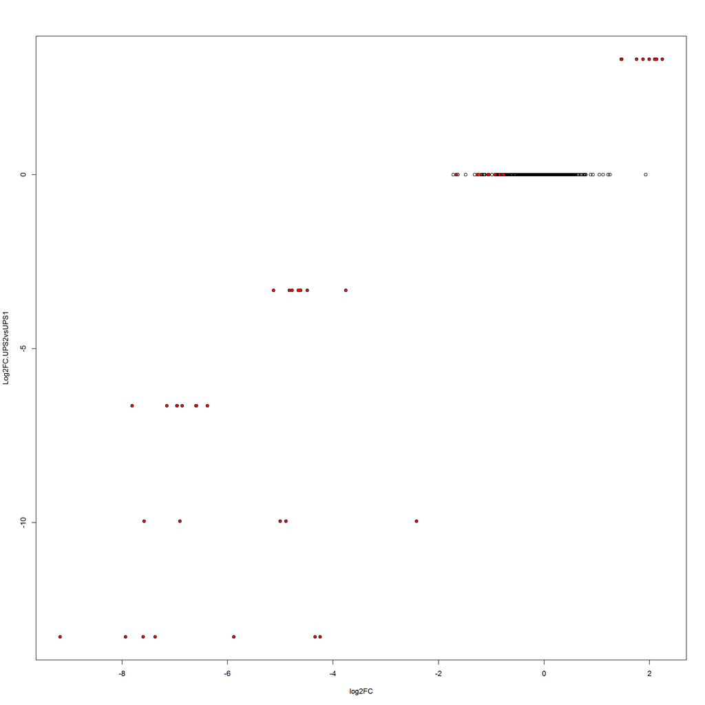

```r
with(res_mRLR, plot(log2FC, Log2FC.UPS2vsUPS1, pch=1))
with(subset(res_mRLR, UPS == "UPS" ), points(log2FC, Log2FC.UPS2vsUPS1, pch=20, col="red"))
```

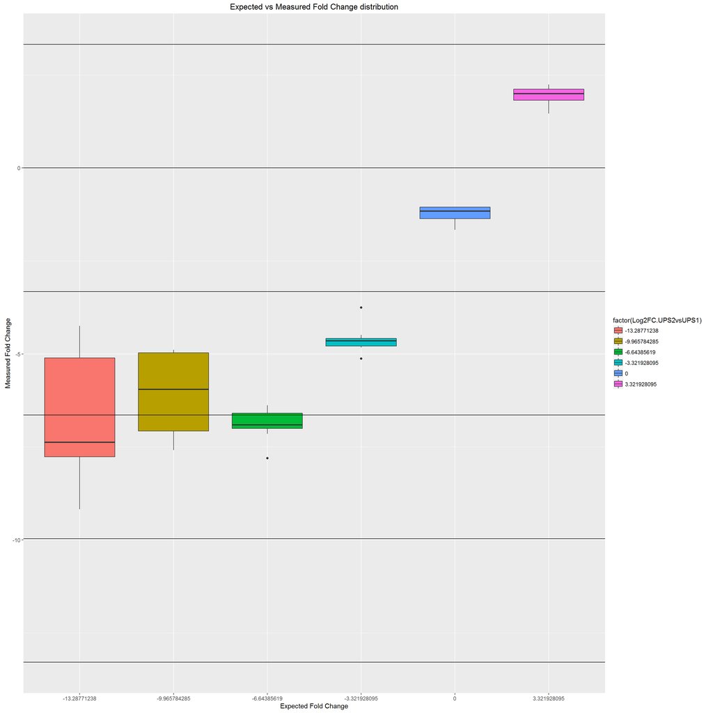

```r
b1 <- ggplot(subset(sigP, UPS=="UPS"), aes(factor(Log2FC.UPS2vsUPS1), log2FC))
b1 + geom_boxplot(aes(fill = factor(Log2FC.UPS2vsUPS1))) + geom_hline(yintercept=unique(sigP$Log2FC.UPS2vsUPS1)) +
  xlab("Expected Fold Change") + ylab("Measured Fold Change") + ggtitle("Expected vs Measured Fold Change distribution")
```

## Plots

There are not a lot of information in the plots generated along the analysis, but althought the analysis of the results will be done in the next point, we should say something at this point.

## Comparison

Finally, as a conclusion, we will see a comparison between all the methods used in 3 tables, in order to observe the details better.

```r
LoessADJ = kable(table(res_mloGadj$threshold_1, res_mloGadj$UPS))
Raw = kable(table(res_mraw$threshold_1, res_mraw$UPS))
RawADJ = kable(table(res_mrawADJ$threshold_1, res_mrawADJ$UPS))
Loess = kable(table(res_mloG$threshold_1, res_mloG$UPS))
VSN = kable(table(res_mVSN$threshold_1, res_mVSN$UPS))
RLR = kable(table(res_mRLR$threshold_1, res_mRLR$UPS))


LoessADJ2 = kable(table(res_mloGadj$threshold_2, res_mloGadj$UPS))
Raw2 = kable(table(res_mraw$threshold_2, res_mraw$UPS))
RawADJ2 = kable(table(res_mrawADJ$threshold_2, res_mrawADJ$UPS))
Loess2 = kable(table(res_mloG$threshold_2, res_mloG$UPS))
VSN2 = kable(table(res_mVSN$threshold_2, res_mVSN$UPS))
RLR2 = kable(table(res_mRLR$threshold_2, res_mRLR$UPS))


LoessADJ3 = kable(table(res_mloGadj$threshold_3, res_mloGadj$UPS))
Raw3 = kable(table(res_mraw$threshold_3, res_mraw$UPS))
RawADJ3 = kable(table(res_mrawADJ$threshold_3, res_mrawADJ$UPS))
Loess3 = kable(table(res_mloG$threshold_3, res_mloG$UPS))
VSN3 = kable(table(res_mVSN$threshold_3, res_mVSN$UPS))
RLR3 = kable(table(res_mRLR$threshold_3, res_mRLR$UPS))



cbind(Raw, RawADJ, Loess,LoessADJ, VSN, RLR) #First threshold
```

```
##      Raw                   RawADJ                Loess
## [1,] "          BKG   UPS" "          BKG   UPS" "          BKG   UPS"
## [2,] "------  -----  ----" "------  -----  ----" "------  -----  ----"
## [3,] "FALSE    1985     4" "FALSE    1986    10" "FALSE    1985     4"
## [4,] "TRUE        1    40" "TRUE        0    34" "TRUE        1    40"
##      LoessADJ              VSN                   RLR
## [1,] "          BKG   UPS" "          BKG   UPS" "          BKG   UPS"
## [2,] "------  -----  ----" "------  -----  ----" "------  -----  ----"
## [3,] "FALSE    1986    10" "FALSE    1985    12" "FALSE    1986    11"
## [4,] "TRUE        0    34" "TRUE        0    32" "TRUE        0    33"
```

```r
cbind(Raw2, RawADJ2, Loess2, LoessADJ2, VSN2, RLR2) #Second threshold
```

```
##      Raw2                  RawADJ2               Loess2
## [1,] "          BKG   UPS" "          BKG   UPS" "          BKG   UPS"
## [2,] "------  -----  ----" "------  -----  ----" "------  -----  ----"
## [3,] "FALSE    1981     4" "FALSE    1986     6" "FALSE    1981     4"
## [4,] "TRUE        5    40" "TRUE        0    38" "TRUE        5    40"
##      LoessADJ2             VSN2                  RLR2
## [1,] "          BKG   UPS" "          BKG   UPS" "          BKG   UPS"
## [2,] "------  -----  ----" "------  -----  ----" "------  -----  ----"
## [3,] "FALSE    1986     6" "FALSE    1985     6" "FALSE    1986     6"
## [4,] "TRUE        0    38" "TRUE        0    38" "TRUE        0    38"
```

```r
cbind(Raw3, RawADJ3, Loess3, LoessADJ3, VSN3, RLR3) #Third threshold
```

```
##      Raw3                  RawADJ3               Loess3
## [1,] "          BKG   UPS" "          BKG   UPS" "          BKG   UPS"
## [2,] "------  -----  ----" "------  -----  ----" "------  -----  ----"
## [3,] "FALSE    1979     2" "FALSE    1984     6" "FALSE    1979     2"
## [4,] "TRUE        5    42" "TRUE        0    38" "TRUE        5    42"
##      LoessADJ3             VSN3                  RLR3
## [1,] "          BKG   UPS" "          BKG   UPS" "          BKG   UPS"
## [2,] "------  -----  ----" "------  -----  ----" "------  -----  ----"
## [3,] "FALSE    1984     6" "FALSE    1984     6" "FALSE    1984     6"
## [4,] "TRUE        0    38" "TRUE        0    38" "TRUE        0    38"
```

**First threshold** We can see how raw data has less false positives using adj.pvalue. Loess normalization method also has less false positives using adj.pvalue. With VSN and RLR method we see no false positives but maybe too many false negatives. We can see that adj.pvalue is more restrictive than pvalue.

**Second threshold** Less restrictive threshold, we can see how the false positives increase in the raw data. The raw data with adj.pval has more true positives, but does not increase the false positives. Exactly the same happens to Loess, and true positives increase in VSN and RLR methods.

**Third threshold** All the cases with adj.pvalue do not change, but raw and Loess cases increase the number of true positives.

**Final conclusion** As we could see, the use of adjusted pvalue increase the restriction of the data, giving us less false positives but also less true positives. Then,in this study the best normalization method is Loess using pvalue not adjusted, but this is a specific case maybe caused by a too well defined data (UPS proteins are sold by SIGMA). Normally, we will need to use the adjust pvalue to have the more realistic results, so at least a check of the adj.pval would be necessary.